# Causes and Effects of Employee Downsizing: A Review and Synthesis

Converted from PDF `Datta-EmployeeDownsizingReview-2010-JOM.pdf` · 68 pages · anchors: page `#pN`, block `#pN-bK`

Page 1

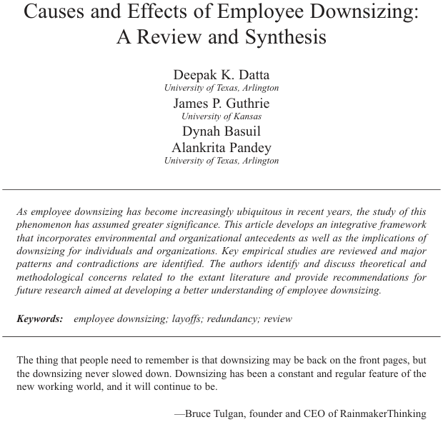

NOTE: figure/graphic rendered as an image from the PDF; its content is not machine-readable text. Caption (if any) follows as the next block.

**text found inside the figure**

Causes and Effects of Employee Downsizing:

A Review and Synthesis

Deepak K. Datta *University of Texas, Arlington*

James P. Guthrie

*University of Kansas*

Dynah Basuil Alankrita Pandey *University of Texas, Arlington*

*As employee downsizing has become increasingly ubiquitous in recent years, the study of this phenomenon has assumed greater significance. This article develops an integrative framework that incorporates environmental and organizational antecedents as well as the implications of downsizing for individuals and organizations. Key empirical studies are reviewed and major patterns and contradictions are identified. The authors identify and discuss theoretical and methodological concerns related to the extant literature and provide recommendations for future research aimed at developing a better understanding of employee downsizing.*

*Keywords:* *employee downsizing; layoffs; redundancy; review*

The thing that people need to remember is that downsizing may be back on the front pages, but the downsizing never slowed down. Downsizing has been a constant and regular feature of the new working world, and it will continue to be.

—Bruce Tulgan, founder and CEO of RainmakerThinking

281

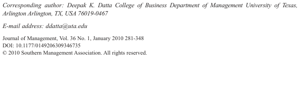

NOTE: figure/graphic rendered as an image from the PDF; its content is not machine-readable text. Caption (if any) follows as the next block.

**text found inside the figure**

*Corresponding author: Deepak K. Datta College of Business Department of Management University of Texas, Arlington Arlington, TX, USA 76019-0467*

*E-mail address: ddatta@uta.edu*

Journal of Management, Vol. 36 No. 1, January 2010 281-348 DOI: 10.1177/0149206309346735 © 2010 Southern Management Association. All rights reserved.

Page 2

282 Journal of Management / January 2010

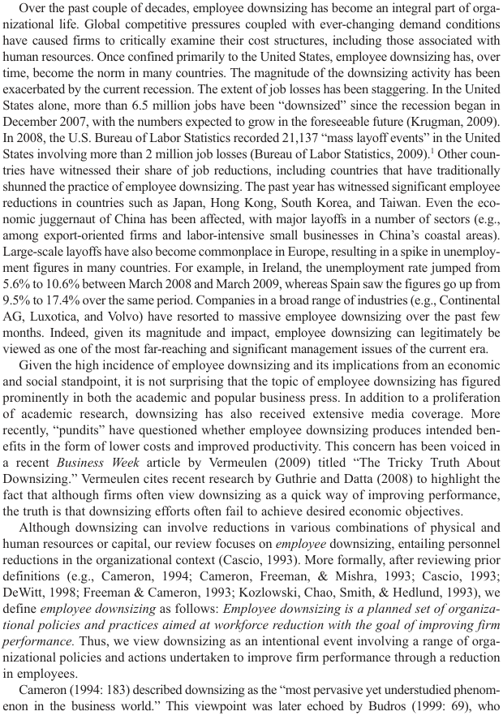

NOTE: figure/graphic rendered as an image from the PDF; its content is not machine-readable text. Caption (if any) follows as the next block.

**text found inside the figure**

Over the past couple of decades, employee downsizing has become an integral part of organizational life. Global competitive pressures coupled with ever-changing demand conditions have caused firms to critically examine their cost structures, including those associated with human resources. Once confined primarily to the United States, employee downsizing has, over time, become the norm in many countries. The magnitude of the downsizing activity has been exacerbated by the current recession. The extent of job losses has been staggering. In the United States alone, more than 6.5 million jobs have been “downsized” since the recession began in December 2007, with the numbers expected to grow in the foreseeable future (Krugman, 2009). In 2008, the U.S. Bureau of Labor Statistics recorded 21,137 “mass layoff events” in the United States involving more than 2 million job losses (Bureau of Labor Statistics, 2009).<sup>1</sup> Other countries have witnessed their share of job reductions, including countries that have traditionally shunned the practice of employee downsizing. The past year has witnessed significant employee reductions in countries such as Japan, Hong Kong, South Korea, and Taiwan. Even the economic juggernaut of China has been affected, with major layoffs in a number of sectors (e.g., among export-oriented firms and labor-intensive small businesses in China’s coastal areas). Large-scale layoffs have also become commonplace in Europe, resulting in a spike in unemployment figures in many countries. For example, in Ireland, the unemployment rate jumped from 5.6% to 10.6% between March 2008 and March 2009, whereas Spain saw the figures go up from 9.5% to 17.4% over the same period. Companies in a broad range of industries (e.g., Continental AG, Luxotica, and Volvo) have resorted to massive employee downsizing over the past few months. Indeed, given its magnitude and impact, employee downsizing can legitimately be viewed as one of the most far-reaching and significant management issues of the current era.

Given the high incidence of employee downsizing and its implications from an economic and social standpoint, it is not surprising that the topic of employee downsizing has figured prominently in both the academic and popular business press. In addition to a proliferation of academic research, downsizing has also received extensive media coverage. More recently, “pundits” have questioned whether employee downsizing produces intended benefits in the form of lower costs and improved productivity. This concern has been voiced in a recent *Business Week* article by Vermeulen (2009) titled “The Tricky Truth About Downsizing.” Vermeulen cites recent research by Guthrie and Datta (2008) to highlight the fact that although firms often view downsizing as a quick way of improving performance, the truth is that downsizing efforts often fail to achieve desired economic objectives.

Although downsizing can involve reductions in various combinations of physical and human resources or capital, our review focuses on *employee* downsizing, entailing personnel reductions in the organizational context (Cascio, 1993). More formally, after reviewing prior definitions (e.g., Cameron, 1994; Cameron, Freeman, & Mishra, 1993; Cascio, 1993; DeWitt, 1998; Freeman & Cameron, 1993; Kozlowski, Chao, Smith, & Hedlund, 1993), we define *employee downsizing* as follows: *Employee downsizing is a planned set of organizational policies and practices aimed at workforce reduction with the goal of improving firm performance.* Thus, we view downsizing as an intentional event involving a range of organizational policies and actions undertaken to improve firm performance through a reduction in employees.

Cameron (1994: 183) described downsizing as the “most pervasive yet understudied phenomenon in the business world.” This viewpoint was later echoed by Budros (1999: 69), who

Page 3

Datta et al. / Causes and Effects of Employee Downsizing 283

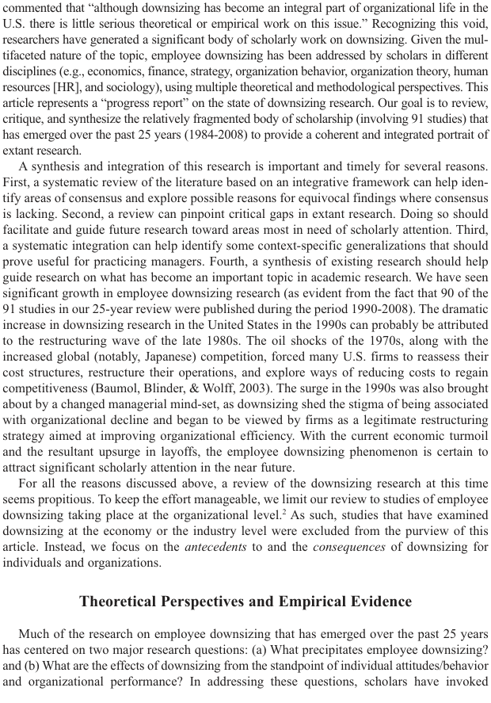

NOTE: figure/graphic rendered as an image from the PDF; its content is not machine-readable text. Caption (if any) follows as the next block.

**text found inside the figure**

commented that “although downsizing has become an integral part of organizational life in the U.S. there is little serious theoretical or empirical work on this issue.” Recognizing this void, researchers have generated a significant body of scholarly work on downsizing. Given the multifaceted nature of the topic, employee downsizing has been addressed by scholars in different disciplines (e.g., economics, finance, strategy, organization behavior, organization theory, human resources [HR], and sociology), using multiple theoretical and methodological perspectives. This article represents a “progress report” on the state of downsizing research. Our goal is to review, critique, and synthesize the relatively fragmented body of scholarship (involving 91 studies) that has emerged over the past 25 years (1984-2008) to provide a coherent and integrated portrait of extant research.

A synthesis and integration of this research is important and timely for several reasons. First, a systematic review of the literature based on an integrative framework can help identify areas of consensus and explore possible reasons for equivocal findings where consensus is lacking. Second, a review can pinpoint critical gaps in extant research. Doing so should facilitate and guide future research toward areas most in need of scholarly attention. Third, a systematic integration can help identify some context-specific generalizations that should prove useful for practicing managers. Fourth, a synthesis of existing research should help guide research on what has become an important topic in academic research. We have seen significant growth in employee downsizing research (as evident from the fact that 90 of the 91 studies in our 25-year review were published during the period 1990-2008). The dramatic increase in downsizing research in the United States in the 1990s can probably be attributed to the restructuring wave of the late 1980s. The oil shocks of the 1970s, along with the increased global (notably, Japanese) competition, forced many U.S. firms to reassess their cost structures, restructure their operations, and explore ways of reducing costs to regain competitiveness (Baumol, Blinder, & Wolff, 2003). The surge in the 1990s was also brought about by a changed managerial mind-set, as downsizing shed the stigma of being associated with organizational decline and began to be viewed by firms as a legitimate restructuring strategy aimed at improving organizational efficiency. With the current economic turmoil and the resultant upsurge in layoffs, the employee downsizing phenomenon is certain to attract significant scholarly attention in the near future.

For all the reasons discussed above, a review of the downsizing research at this time seems propitious. To keep the effort manageable, we limit our review to studies of employee downsizing taking place at the organizational level.<sup>2</sup> As such, studies that have examined downsizing at the economy or the industry level were excluded from the purview of this article. Instead, we focus on the *antecedents* to and the *consequences* of downsizing for individuals and organizations.

**Theoretical Perspectives and Empirical Evidence**

Much of the research on employee downsizing that has emerged over the past 25 years has centered on two major research questions: (a) What precipitates employee downsizing? and (b) What are the effects of downsizing from the standpoint of individual attitudes/behavior and organizational performance? In addressing these questions, scholars have invoked

Page 4

284 Journal of Management / January 2010

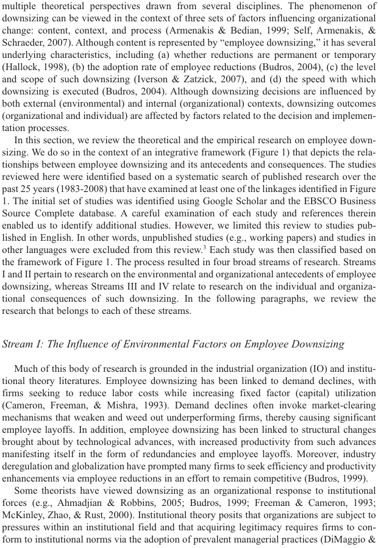

NOTE: figure/graphic rendered as an image from the PDF; its content is not machine-readable text. Caption (if any) follows as the next block.

**text found inside the figure**

multiple theoretical perspectives drawn from several disciplines. The phenomenon of downsizing can be viewed in the context of three sets of factors influencing organizational change: content, context, and process (Armenakis & Bedian, 1999; Self, Armenakis, & Schraeder, 2007). Although content is represented by “employee downsizing,” it has several underlying characteristics, including (a) whether reductions are permanent or temporary (Hallock, 1998), (b) the adoption rate of employee reductions (Budros, 2004), (c) the level and scope of such downsizing (Iverson & Zatzick, 2007), and (d) the speed with which downsizing is executed (Budros, 2004). Although downsizing decisions are influenced by both external (environmental) and internal (organizational) contexts, downsizing outcomes (organizational and individual) are affected by factors related to the decision and implementation processes.

*Stream I: The Influence of Environmental Factors on Employee Downsizing*

Much of this body of research is grounded in the industrial organization (IO) and institutional theory literatures. Employee downsizing has been linked to demand declines, with firms seeking to reduce labor costs while increasing fixed factor (capital) utilization (Cameron, Freeman, & Mishra, 1993). Demand declines often invoke market-clearing mechanisms that weaken and weed out underperforming firms, thereby causing significant employee layoffs. In addition, employee downsizing has been linked to structural changes brought about by technological advances, with increased productivity from such advances manifesting itself in the form of redundancies and employee layoffs. Moreover, industry deregulation and globalization have prompted many firms to seek efficiency and productivity enhancements via employee reductions in an effort to remain competitive (Budros, 1999).

Some theorists have viewed downsizing as an organizational response to institutional forces (e.g., Ahmadjian & Robbins, 2005; Budros, 1999; Freeman & Cameron, 1993; McKinley, Zhao, & Rust, 2000). Institutional theory posits that organizations are subject to pressures within an institutional field and that acquiring legitimacy requires firms to conform to institutional norms via the adoption of prevalent managerial practices (DiMaggio &

Page 5

Datta et al. / Causes and Effects of Employee Downsizing 285

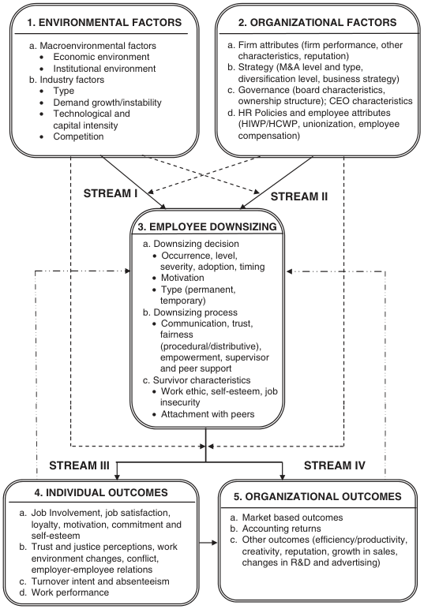

NOTE: figure/graphic rendered as an image from the PDF; its content is not machine-readable text. Caption (if any) follows as the next block.

**text found inside the figure**

**1. ENVIRONMENTAL FACTORS**

a. Macroenvironmental factors • Economic environment • Institutional environment b. Industry factors • Type • Demand growth/instability • Technological and capital intensity • Competition

**2. ORGANIZATIONAL FACTORS**

a. Firm attributes (firm performance, other characteristics, reputation) b. Strategy (M&A level and type, diversification level, business strategy) c. Governance (board characteristics, ownership structure); CEO characteristics d. HR Policies and employee attributes (HIWP/HCWP, unionization, employee compensation)

**3. EMPLOYEE DOWNSIZING**

a. Downsizing decision • Occurrence, level, severity, adoption, timing • Motivation • Type (permanent, temporary) b. Downsizing process • Communication, trust, fairness (procedural/distributive), empowerment, supervisor and peer support c. Survivor characteristics • Work ethic, self-esteem, job insecurity • Attachment with peers

**5. ORGANIZATIONAL OUTCOMES**

a. Market based outcomes b. Accounting returns c. Other outcomes (efficiency/productivity, creativity, reputation, growth in sales, changes in R&D and advertising)

**STREAM I STREAM II**

**STREAM III**

**4. INDIVIDUAL OUTCOMES**

a. Job Involvement, job satisfaction, loyalty, motivation, commitment and self-esteem b. Trust and justice perceptions, work environment changes, conflict, employer-employee relations c. Turnover intent and absenteeism d. Work performance

**STREAM IV**

Direct effect Moderating effect Feedback effect

**Figure 1 An Integrative Model of Employee Downsizing**

Page 6

286 Journal of Management / January 2010

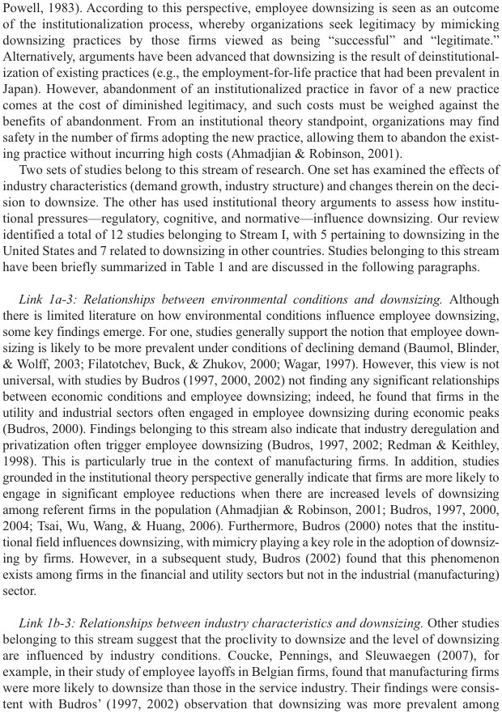

NOTE: figure/graphic rendered as an image from the PDF; its content is not machine-readable text. Caption (if any) follows as the next block.

**text found inside the figure**

Powell, 1983). According to this perspective, employee downsizing is seen as an outcome of the institutionalization process, whereby organizations seek legitimacy by mimicking downsizing practices by those firms viewed as being “successful” and “legitimate.” Alternatively, arguments have been advanced that downsizing is the result of deinstitutionalization of existing practices (e.g., the employment-for-life practice that had been prevalent in Japan). However, abandonment of an institutionalized practice in favor of a new practice comes at the cost of diminished legitimacy, and such costs must be weighed against the benefits of abandonment. From an institutional theory standpoint, organizations may find safety in the number of firms adopting the new practice, allowing them to abandon the existing practice without incurring high costs (Ahmadjian & Robinson, 2001).

Two sets of studies belong to this stream of research. One set has examined the effects of industry characteristics (demand growth, industry structure) and changes therein on the decision to downsize. The other has used institutional theory arguments to assess how institutional pressures—regulatory, cognitive, and normative—influence downsizing. Our review identified a total of 12 studies belonging to Stream I, with 5 pertaining to downsizing in the United States and 7 related to downsizing in other countries. Studies belonging to this stream have been briefly summarized in Table 1 and are discussed in the following paragraphs.

*Link 1a-3: Relationships between environmental conditions and downsizing.* Although there is limited literature on how environmental conditions influence employee downsizing, some key findings emerge. For one, studies generally support the notion that employee downsizing is likely to be more prevalent under conditions of declining demand (Baumol, Blinder, & Wolff, 2003; Filatotchev, Buck, & Zhukov, 2000; Wagar, 1997). However, this view is not universal, with studies by Budros (1997, 2000, 2002) not finding any significant relationships between economic conditions and employee downsizing; indeed, he found that firms in the utility and industrial sectors often engaged in employee downsizing during economic peaks (Budros, 2000). Findings belonging to this stream also indicate that industry deregulation and privatization often trigger employee downsizing (Budros, 1997, 2002; Redman & Keithley, 1998). This is particularly true in the context of manufacturing firms. In addition, studies grounded in the institutional theory perspective generally indicate that firms are more likely to engage in significant employee reductions when there are increased levels of downsizing among referent firms in the population (Ahmadjian & Robinson, 2001; Budros, 1997, 2000, 2004; Tsai, Wu, Wang, & Huang, 2006). Furthermore, Budros (2000) notes that the institutional field influences downsizing, with mimicry playing a key role in the adoption of downsizing by firms. However, in a subsequent study, Budros (2002) found that this phenomenon exists among firms in the financial and utility sectors but not in the industrial (manufacturing) sector.

*Link 1b-3: Relationships between industry characteristics and downsizing.* Other studies belonging to this stream suggest that the proclivity to downsize and the level of downsizing are influenced by industry conditions. Coucke, Pennings, and Sleuwaegen (2007), for example, in their study of employee layoffs in Belgian firms, found that manufacturing firms were more likely to downsize than those in the service industry. Their findings were consistent with Budros’ (1997, 2002) observation that downsizing was more prevalent among

*(Text continues on p. 291)*

Page 7

287

**Table 1**

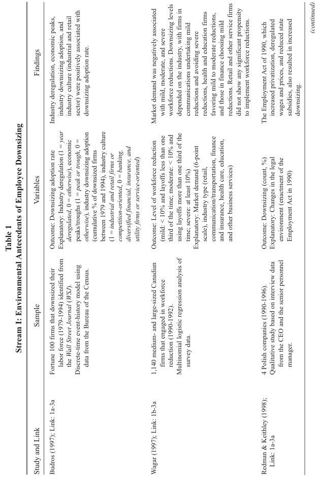

NOTE: figure/graphic rendered as an image from the PDF; its content is not machine-readable text. Caption (if any) follows as the next block.

**text found inside the figure**

**Stream I: Environmental Antecedents of Employee Downsizing**

Study and Link

Budros (1997); Link: 1a-3a

Wagar (1997); Link: 1b-3a

Redman & Keithley (1998);

Link: 1a-3a

Sample

Fortune 100 firms that downsized their

labor force (1979-1994) identified from

the *Wall Street Journal* (*WSJ*).

Discrete-time event-history model using

data from the Bureau of the Census.

1,140 medium- and large-sized Canadian firms that engaged in workforce

reduction (1990-1992).

Multinomial logistic regression analysis of

survey data.

4 Polish companies (1990-1996). Qualitative study based on interview data

from the CEO and the senior personnel

manager.

Variables

Outcome: Downsizing adoption rate

Explanatory: Industry deregulation (1 = *year*

*deregulated*, 0 = *otherwise*), economic

peaks/troughs (1 = *peak or trough*, 0 =

*otherwise*), industry downsizing adoption

(cumulative % of downsized firms

between 1979 and 1994), industry culture

(1 = *industrial and retail firms or*

*competition-oriented*, 0 = *banking,*

*diversified financial, insurance, and*

*utility firms or service-oriented*)

Outcome: Level of workforce reduction

(mild: < 10% and layoffs less than one

third of the time; moderate: < 10% and

using layoffs more than one third of the

time; severe: at least 10%)

Explanatory: Market demand (6-point

scale), industry type (retail,

communication/transportation, finance

and insurance, health care, education,

and other business services)

Outcome: Downsizing (count, %)

Explanatory: Changes in the legal

environment (enactment of the

Employment Act in 1990)

Findings

Industry deregulation, economic peaks,

industry downsizing adoption, and

industry culture (industrial and retail

sector) were positively associated with

downsizing adoption rate.

Market demand was negatively associated

with mild, moderate, and severe

workforce reductions. Downsizing levels

depended on the industry, with firms in

communications undertaking mild

reductions and avoiding severe

reductions, health and education firms

favoring mild to moderate reductions,

and those in finance choosing mild

reductions. Retail and other service firms

did not show any significant propensity

to implement workforce reductions.

The Employment Act of 1990, which

increased privatization, deregulated

wages and prices, and reduced state

subsidies, also resulted in increased

downsizing.

*(continued)*

Page 8

288

**Table 1 (continued)**

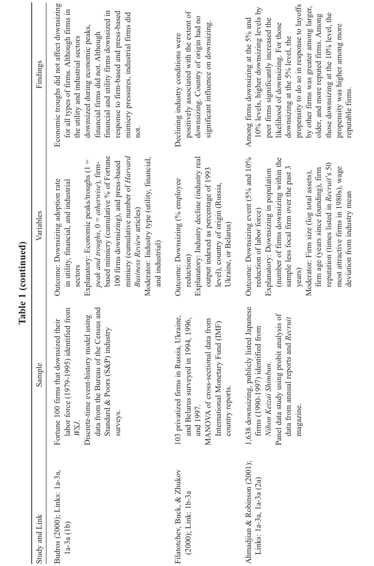

NOTE: figure/graphic rendered as an image from the PDF; its content is not machine-readable text. Caption (if any) follows as the next block.

**text found inside the figure**

Study and Link

Budros (2000); Links: 1a-3a,

1a-3a (1b)

Filatotchev, Buck, & Zhukov

(2000); Link: 1b-3a

Ahmadjian & Robinson (2001);

Links: 1a-3a, 1a-3a (2a)

Sample

Fortune 100 firms that downsized their

labor force (1979-1995) identified from

*WSJ*.

Discrete-time event-history model using

data from the Bureau of the Census and

Standard & Poors (S&P) industry

surveys.

103 privatized firms in Russia, Ukraine, and Belarus surveyed in 1994, 1996,

and 1997.

MANOVA of cross-sectional data from

International Monetary Fund (IMF)

country reports.

1,638 downsizing, publicly listed Japanese firms (1990-1997) identified from

*Nihon Keizai Shimbun*.

Panel data study using probit analysis of

data from annual reports and *Recruit*

magazine.

Variables

Outcome: Downsizing adoption rate

in utility, financial, and industrial

sectors

Explanatory: Economic peaks/troughs (1 =

*peak and troughs*, 0 = *otherwise*), firm-

based mimicry (cumulative % of Fortune

100 firms downsizing), and press-based mimicry (cumulative number of *Harvard*

*Business Review* articles)

Moderator: Industry type (utility, financial,

and industrial)

Outcome: Downsizing (% employee

reduction)

Explanatory: Industry decline (industry real

output indexed as percentage of 1993

level), country of origin (Russia,

Ukraine, or Belarus)

Outcome: Downsizing event (5% and 10%

reduction of labor force)

Explanatory: Downsizing in population

(number of firms downsizing within the

sample less focal firm over the past 3

years)

Moderator: Firm size (log total assets),

firm age (years since founding), firm

reputation (times listed in *Recruit*’s 50

most attractive firms in 1980s), wage

deviation from industry mean

Findings

Economic troughs did not affect downsizing

for all types of firms. Although firms in

the utility and industrial sectors

downsized during economic peaks,

financial firms did not. Although

financial and utility firms downsized in

response to firm-based and press-based

mimicry pressures, industrial firms did

not.

Declining industry conditions were

positively associated with the extent of

downsizing. Country of origin had no

significant influence on downsizing.

Among firms downsizing at the 5% and

10% levels, higher downsizing levels by peer firms significantly increased the

likelihood of downsizing. For those

downsizing at the 5% level, the

propensity to do so in response to layoffs

by other firms was greater among larger,

older, and more reputed firms. Among

those downsizing at the 10% level, the

propensity was higher among more

reputable firms.

Page 9

289

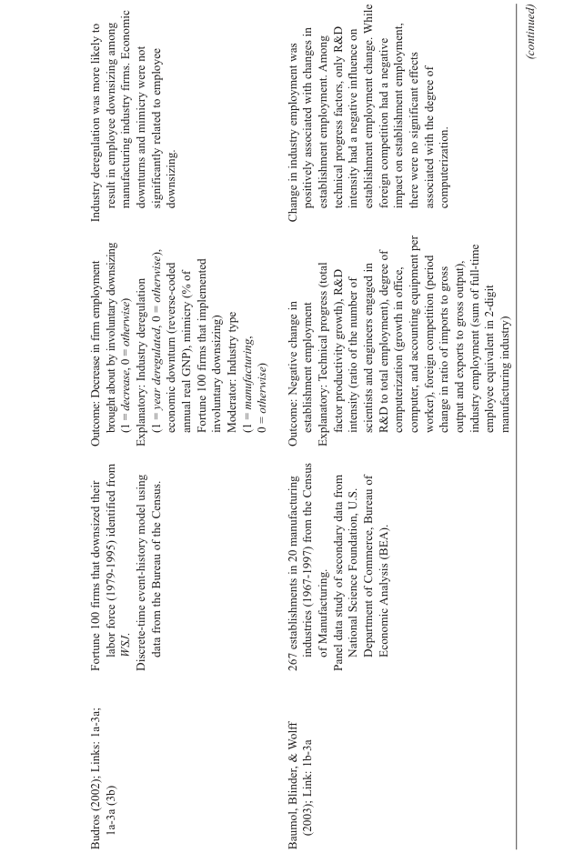

NOTE: figure/graphic rendered as an image from the PDF; its content is not machine-readable text. Caption (if any) follows as the next block.

**text found inside the figure**

Budros (2002); Links: 1a-3a;

1a-3a (3b)

Baumol, Blinder, & Wolff

(2003); Link: 1b-3a

Fortune 100 firms that downsized their

labor force (1979-1995) identified from

*WSJ*.

Discrete-time event-history model using

data from the Bureau of the Census.

267 establishments in 20 manufacturing industries (1967-1997) from the Census

of Manufacturing.

Panel data study of secondary data from

National Science Foundation, U.S.

Department of Commerce, Bureau of

Economic Analysis (BEA).

Outcome: Decrease in firm employment

brought about by involuntary downsizing

(1 = *decrease*, 0 = *otherwise*)

Explanatory: Industry deregulation

(1 = *year deregulated*, 0 = *otherwise*),

economic downturn (reverse-coded

annual real GNP), mimicry (% of

Fortune 100 firms that implemented

involuntary downsizing)

Moderator: Industry type

(1 = *manufacturing*,

0 = *otherwise*)

Outcome: Negative change in

establishment employment

Explanatory: Technical progress (total

factor productivity growth), R&D

intensity (ratio of the number of

scientists and engineers engaged in

R&D to total employment), degree of

computerization (growth in office,

computer, and accounting equipment per

worker), foreign competition (period

change in ratio of imports to gross

output and exports to gross output),

industry employment (sum of full-time

employee equivalent in 2-digit

manufacturing industry)

Industry deregulation was more likely to

result in employee downsizing among

manufacturing industry firms. Economic

downturns and mimicry were not

significantly related to employee

downsizing.

Change in industry employment was

positively associated with changes in

establishment employment. Among

technical progress factors, only R&D

intensity had a negative influence on

establishment employment change. While

foreign competition had a negative

impact on establishment employment,

there were no significant effects

associated with the degree of

computerization.

*(continued)*

Page 10

290

**Table 1 (continued)**

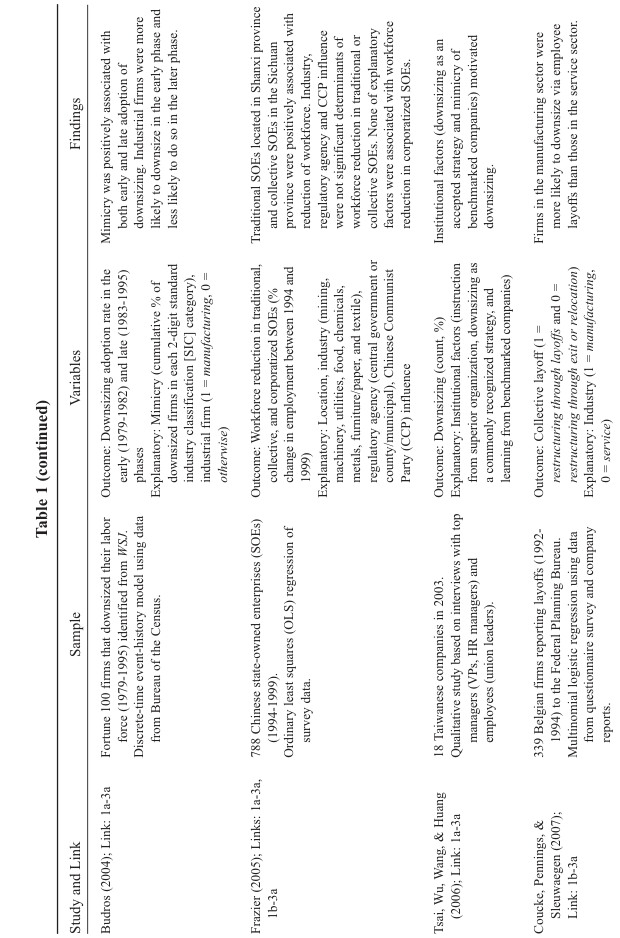

NOTE: figure/graphic rendered as an image from the PDF; its content is not machine-readable text. Caption (if any) follows as the next block.

**text found inside the figure**

Study and Link

Budros (2004); Link: 1a-3a

Frazier (2005); Links: 1a-3a,

1b-3a

Tsai, Wu, Wang, & Huang

(2006); Link: 1a-3a

Coucke, Pennings, &

Sleuwaegen (2007);

Link: 1b-3a

Sample

Fortune 100 firms that downsized their labor

force (1979-1995) identified from *WSJ*.

Discrete-time event-history model using data

from Bureau of the Census.

788 Chinese state-owned enterprises (SOEs) (1994-1999).

Ordinary least squares (OLS) regression of

survey data.

18 Taiwanese companies in 2003. Qualitative study based on interviews with top

managers (VPs, HR managers) and

employees (union leaders).

339 Belgian firms reporting layoffs (1992- 1994) to the Federal Planning Bureau. Multinomial logistic regression using data

from questionnaire survey and company

reports.

Variables

Outcome: Downsizing adoption rate in the

early (1979-1982) and late (1983-1995)

phases

Explanatory: Mimicry (cumulative % of

downsized firms in each 2-digit standard

industry classification [SIC] category),

industrial firm (1 = *manufacturing*, 0 =

*otherwise*)

Outcome: Workforce reduction in traditional,

collective, and corporatized SOEs (%

change in employment between 1994 and

1999) Explanatory: Location, industry (mining,

machinery, utilities, food, chemicals,

metals, furniture/paper, and textile),

regulatory agency (central government or

county/municipal), Chinese Communist

Party (CCP) influence

Outcome: Downsizing (count, %)

Explanatory: Institutional factors (instruction

from superior organization, downsizing as

a commonly recognized strategy, and

learning from benchmarked companies)

Outcome: Collective layoff (1 =

*restructuring through layoffs* and 0 =

*restructuring through exit or relocation*)

Explanatory: Industry (1 = *manufacturing*,

0 = *service*)

Findings

Mimicry was positively associated with

both early and late adoption of

downsizing. Industrial firms were more

likely to downsize in the early phase and

less likely to do so in the later phase.

Traditional SOEs located in Shanxi province

and collective SOEs in the Sichuan

province were positively associated with

reduction of workforce. Industry,

regulatory agency and CCP influence

were not significant determinants of

workforce reduction in traditional or

collective SOEs. None of explanatory

factors were associated with workforce

reduction in corporatized SOEs.

Institutional factors (downsizing as an

accepted strategy and mimicry of

benchmarked companies) motivated

downsizing.

Firms in the manufacturing sector were

more likely to downsize via employee

layoffs than those in the service sector.

Page 11

Datta et al. / Causes and Effects of Employee Downsizing 291

In sum, the limited Stream I research has left many questions unanswered. This translates into significant opportunities for future research aimed at understanding the role of environmental factors in determining the incidence and level of employee downsizing. Possible research questions for future research are discussed in the final section of the article.

### *Stream II: Organizational Influences on Employee Downsizing*

The second body of research on the determinants of employee downsizing focuses on factors related to the organizational context as drivers of such downsizing. A key premise underlying this body of research is that the primary objective of employee downsizing is more efficient utilization of human resources. The organizational efficiency perspective draws on the resource-based view of the firm to argue that employee downsizing, with attendant cost savings, is a viable strategy in redressing organizational performance declines. In the context of underperforming firms, employee downsizing is seen as an important signal communicating organizational intentions and efforts at bridging the gap between stakeholders’ expectations and achieved performance. On the other hand, layoff announcements made in the absence of poor performance may be perceived as a proactive measure aimed at maintaining current competitive advantage. Alternatively, it may signal private information held by managers of anticipated declining demand or dwindling firm economic health (Foster, 2002). The organizational efficiency perspective has also been used to justify downsizing in the aftermath of mergers and acquisitions (M&As). When similar firms merge, consolidation of operations generates personnel redundancies, undercutting financial performance. In such a context, employee downsizing represents a vehicle by which the merged entity can eliminate slack and realize operational synergies (O’Shaughnessy & Flanagan, 1998).

Research on the organizational antecedents of employee downsizing has also drawn extensively on agency theory arguments (e.g., Filatotchev et al., 2000; Perry & Shivdasani, 2005). Agency theory posits that weak governance mechanisms lead to managers engaging in activities that further their own interests at the expense of shareholders (Eisenhardt, 1989; Fama & Jensen, 1983). From this perspective, managers have a disincentive to downsize because of the pecuniary and nonpecuniary benefits derived from running larger and more

Page 12

292 Journal of Management / January 2010

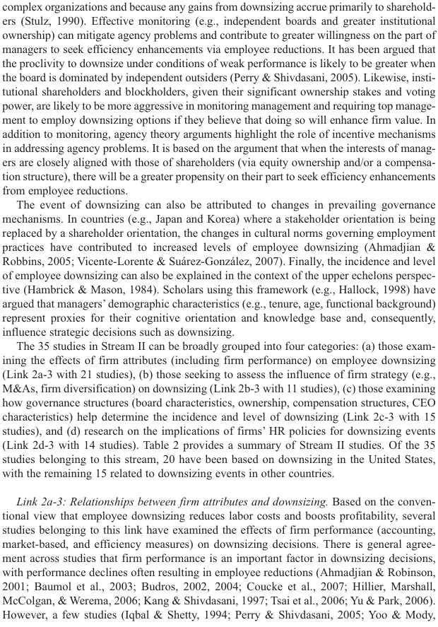

NOTE: figure/graphic rendered as an image from the PDF; its content is not machine-readable text. Caption (if any) follows as the next block.

**text found inside the figure**

complex organizations and because any gains from downsizing accrue primarily to shareholders (Stulz, 1990). Effective monitoring (e.g., independent boards and greater institutional ownership) can mitigate agency problems and contribute to greater willingness on the part of managers to seek efficiency enhancements via employee reductions. It has been argued that the proclivity to downsize under conditions of weak performance is likely to be greater when the board is dominated by independent outsiders (Perry & Shivdasani, 2005). Likewise, institutional shareholders and blockholders, given their significant ownership stakes and voting power, are likely to be more aggressive in monitoring management and requiring top management to employ downsizing options if they believe that doing so will enhance firm value. In addition to monitoring, agency theory arguments highlight the role of incentive mechanisms in addressing agency problems. It is based on the argument that when the interests of managers are closely aligned with those of shareholders (via equity ownership and/or a compensation structure), there will be a greater propensity on their part to seek efficiency enhancements from employee reductions.

The event of downsizing can also be attributed to changes in prevailing governance mechanisms. In countries (e.g., Japan and Korea) where a stakeholder orientation is being replaced by a shareholder orientation, the changes in cultural norms governing employment practices have contributed to increased levels of employee downsizing (Ahmadjian & Robbins, 2005; Vicente-Lorente & Suárez-González, 2007). Finally, the incidence and level of employee downsizing can also be explained in the context of the upper echelons perspective (Hambrick & Mason, 1984). Scholars using this framework (e.g., Hallock, 1998) have argued that managers’ demographic characteristics (e.g., tenure, age, functional background) represent proxies for their cognitive orientation and knowledge base and, consequently, influence strategic decisions such as downsizing.

The 35 studies in Stream II can be broadly grouped into four categories: (a) those examining the effects of firm attributes (including firm performance) on employee downsizing (Link 2a-3 with 21 studies), (b) those seeking to assess the influence of firm strategy (e.g., M&As, firm diversification) on downsizing (Link 2b-3 with 11 studies), (c) those examining how governance structures (board characteristics, ownership, compensation structures, CEO characteristics) help determine the incidence and level of downsizing (Link 2c-3 with 15 studies), and (d) research on the implications of firms’ HR policies for downsizing events (Link 2d-3 with 14 studies). Table 2 provides a summary of Stream II studies. Of the 35 studies belonging to this stream, 20 have been based on downsizing in the United States, with the remaining 15 related to downsizing events in other countries.

*Link 2a-3: Relationships between firm attributes and downsizing.* Based on the conventional view that employee downsizing reduces labor costs and boosts profitability, several studies belonging to this link have examined the effects of firm performance (accounting, market-based, and efficiency measures) on downsizing decisions. There is general agreement across studies that firm performance is an important factor in downsizing decisions, with performance declines often resulting in employee reductions (Ahmadjian & Robinson, 2001; Baumol et al., 2003; Budros, 2002, 2004; Coucke et al., 2007; Hillier, Marshall, McColgan, & Werema, 2006; Kang & Shivdasani, 1997; Tsai et al., 2006; Yu & Park, 2006). However, a few studies (Iqbal & Shetty, 1994; Perry & Shivdasani, 2005; Yoo & Mody,

*(Text continues on p. 305)*

Page 13

293

**Table 2**

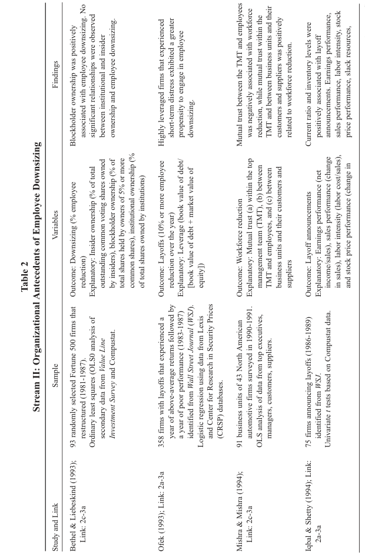

NOTE: figure/graphic rendered as an image from the PDF; its content is not machine-readable text. Caption (if any) follows as the next block.

**text found inside the figure**

**Stream II: Organizational Antecedents of Employee Downsizing**

Study and Link

Bethel & Liebeskind (1993);

Link: 2c-3a

Ofek (1993); Link: 2a-3a

Mishra & Mishra (1994);

Link: 2c-3a

Iqbal & Shetty (1994); Link:

2a-3a

Sample

93 randomly selected Fortune 500 firms that restructured (1981-1987).

Ordinary least squares (OLS0 analysis of

secondary data from *Value Line*

*Investment Survey* and Compustat.

358 firms with layoffs that experienced a year of above-average returns followed by

a year of poor performance (1983-1987)

identified from *Wall Street Journal* (*WSJ*).

Logistic regression using data from Lexis

and Center for Research in Security Prices

(CRSP) databases.

91 business units of 43 North American automotive firms surveyed in 1990-1991.

OLS analysis of data from top executives,

managers, customers, suppliers.

75 firms announcing layoffs (1986-1989) identified from *WSJ*.

Univariate *t* tests based on Compustat data.

Variables

Outcome: Downsizing (% employee

reduction)

Explanatory: Insider ownership (% of total

outstanding common voting shares owned

by insiders), blockholder ownership (% of

total shares held by owners of 5% or more

common shares), institutional ownership (%

of total shares owned by institutions)

Outcome: Layoffs (10% or more employee

reduction over the year)

Explanatory: Leverage (book value of debt/

[book value of debt + market value of

equity])

Outcome: Workforce reduction

Explanatory: Mutual trust (a) within the top

management team (TMT), (b) between

TMT and employees, and (c) between

business units and their customers and

suppliers

Outcome: Layoff announcements

Explanatory: Earnings performance (net

income/sales), sales performance (change

in sales), labor intensity (labor cost/sales),

and stock price performance (change in

Findings

Blockholder ownership was positively

associated with employee downsizing. No

significant relationships were observed

between institutional and insider

ownership and employee downsizing.

Highly leveraged firms that experienced

short-term distress exhibited a greater

propensity to engage in employee

downsizing.

Mutual trust between the TMT and employees

was negatively associated with workforce

reduction, while mutual trust within the

TMT and between business units and their

customers and suppliers was positively

related to workforce reduction.

Current ratio and inventory levels were

positively associated with layoff

announcements. Earnings performance,

sales performance, labor intensity, stock

price performance, slack resources,

*(continued)*

Page 14

294

**Table 2 (continued)**

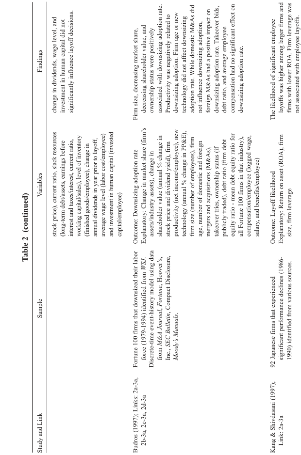

NOTE: figure/graphic rendered as an image from the PDF; its content is not machine-readable text. Caption (if any) follows as the next block.

**text found inside the figure**

Study and Link

Budros (1997); Links: 2a-3a,

2b-3a, 2c-3a, 2d-3a

Kang & Shivdasani (1997);

Link: 2a-3a

Sample

Fortune 100 firms that downsized their labor

force (1979-1994) identified from *WSJ*.

Discrete-time event-history model using data

from *M&A Journal*, *Fortune*, Hoover’s,

Inc., *SEC Bulletin*, Compact Disclosure,

*Moody’s Manuals*.

92 Japanese firms that experienced significant performance declines (1986-

1990) identified from various sources.

Variables

stock price), current ratio, slack resources

(long-term debt/assets, earnings before

interest and taxes/interest, current ratio,

working capital/sales), level of inventory

(finished goods/employee), change in

annual dividends in year prior to layoff,

average wage level (labor cost/employee)

and investment in human capital (invested

capital/employee)

Outcome: Downsizing adoption rate

Explanatory: Change in market share (firm’s

assets/industry assets), change in

shareholder value (annual % change in

stock price and dividend yield), firm

productivity (net income/employee), new

technology (annual % change in PP&E),

firm size (number of employees), firm

age, number of domestic and foreign

mergers and acquisitions (M&As),

takeover tries, ownership status (if

publicly traded), debt ratio (firm debt

equity ratio - mean debt equity ratio for

all Fortune 100 firms in that industry),

compensation/employee (logged wage,

salary, and benefits/employee)

Outcome: Layoff likelihood

Explanatory: Return on asset (ROA), firm

size, firm leverage

Findings

change in dividends, wage level, and

investment in human capital did not

significantly influence layoff decisions.

Firm size, decreasing market share,

decreasing shareholder value, and

ownership status were positively

associated with downsizing adoption rate.

Productivity was negatively related to

downsizing adoption. Firm age or new

technology did not affect downsizing

adoption rate. While domestic M&As did

not influence downsizing adoption,

foreign M&As had a positive impact on

downsizing adoption rate. Takeover bids,

debt ratio, and average employee

compensation had no significant effect on

downsizing adoption rate.

The likelihood of significant employee

layoffs was higher among larger firms and

firms with lower ROA. Firm leverage was

not associated with employee layoffs.

Page 15

295

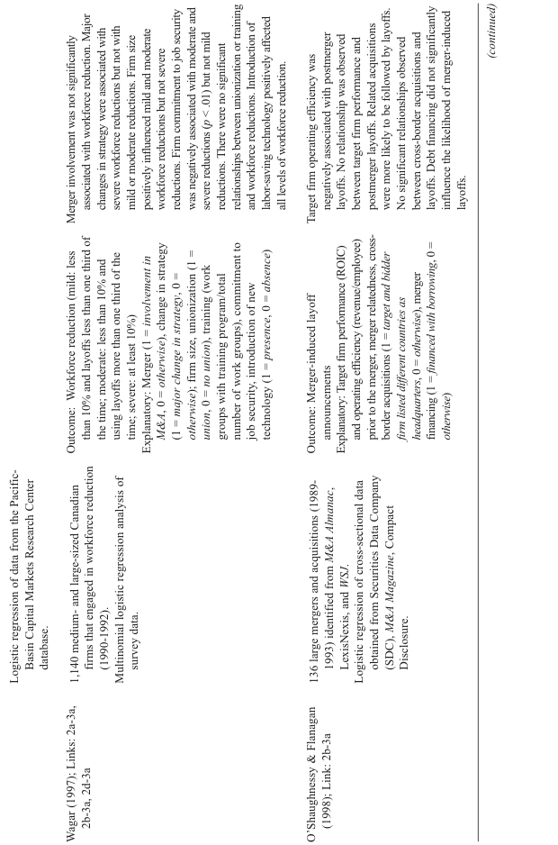

NOTE: figure/graphic rendered as an image from the PDF; its content is not machine-readable text. Caption (if any) follows as the next block.

**text found inside the figure**

Wagar (1997); Links: 2a-3a,

2b-3a, 2d-3a

O’Shaughnessy & Flanagan

(1998); Link: 2b-3a

Logistic regression of data from the Pacific-

Basin Capital Markets Research Center

database.

1,140 medium- and large-sized Canadian firms that engaged in workforce reduction

(1990-1992).

Multinomial logistic regression analysis of

survey data.

136 large mergers and acquisitions (1989- 1993) identified from *M&A Almanac*, LexisNexis, and *WSJ*.

Logistic regression of cross-sectional data

obtained from Securities Data Company

(SDC), *M&A Magazine*, Compact

Disclosure.

Outcome: Workforce reduction (mild: less

than 10% and layoffs less than one third of

the time; moderate: less than 10% and

using layoffs more than one third of the

time; severe: at least 10%)

Explanatory: Merger (1 = *involvement in*

*M&A*, 0 = *otherwise*), change in strategy

(1 = *major change in strategy*, 0 =

*otherwise*); firm size, unionization (1 =

*union*, 0 = *no union*), training (work

groups with training program/total

number of work groups), commitment to

job security, introduction of new

technology (1 = *presence*, 0 = *absence*)

Outcome: Merger-induced layoff

announcements

Explanatory: Target firm performance (ROIC)

and operating efficiency (revenue/employee)

prior to the merger, merger relatedness, cross-

border acquisitions (1 = *target and bidder*

*firm listed different countries as*

*headquarters*, 0 = *otherwise*), merger

financing (1 = *financed with borrowing*, 0 =

*otherwise*)

Merger involvement was not significantly

associated with workforce reduction. Major

changes in strategy were associated with

severe workforce reductions but not with

mild or moderate reductions. Firm size

positively influenced mild and moderate

workforce reductions but not severe

reductions. Firm commitment to job security

was negatively associated with moderate and

severe reductions (*p* < .01) but not mild

reductions. There were no significant

relationships between unionization or training

and workforce reductions. Introduction of

labor-saving technology positively affected

all levels of workforce reduction.

Target firm operating efficiency was

negatively associated with postmerger

layoffs. No relationship was observed

between target firm performance and

postmerger layoffs. Related acquisitions

were more likely to be followed by layoffs.

No significant relationships observed

between cross-border acquisitions and

layoffs. Debt financing did not significantly

influence the likelihood of merger-induced

layoffs.

*(continued)*

Page 16

296

**Table 2 (continued)**

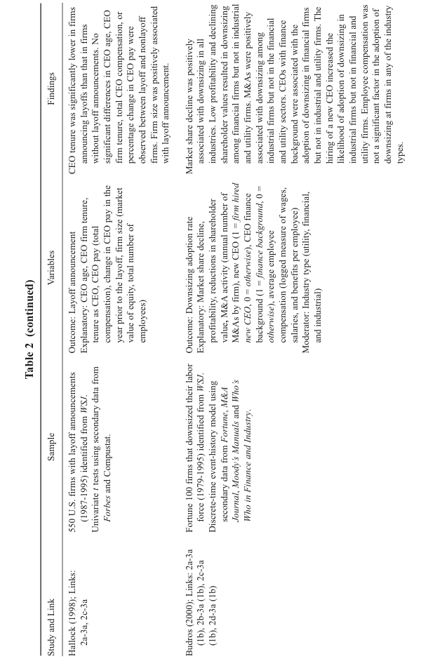

NOTE: figure/graphic rendered as an image from the PDF; its content is not machine-readable text. Caption (if any) follows as the next block.

**text found inside the figure**

Study and Link

Hallock (1998); Links:

2a-3a, 2c-3a

Budros (2000); Links: 2a-3a

(1b), 2b-3a (1b), 2c-3a

(1b), 2d-3a (1b)

Sample

550 U.S. firms with layoff announcements (1987-1995) identified from *WSJ*.

Univariate *t* tests using secondary data from

*Forbes* and Compustat.

Fortune 100 firms that downsized their labor

force (1979-1995) identified from *WSJ*.

Discrete-time event-history model using

secondary data from *Fortune*, *M&A*

*Journal*, *Moody’s Manuals* and *Who’s*

*Who in Finance and Industry*.

Variables

Outcome: Layoff announcement

Explanatory: CEO age, CEO firm tenure,

tenure as CEO, CEO pay (total

compensation), change in CEO pay in the

year prior to the layoff, firm size (market

value of equity, total number of

employees)

Outcome: Downsizing adoption rate

Explanatory: Market share decline,

profitability, reductions in shareholder

value**,** M&A activity (annual number of

M&As by firm), new CEO (1 = *firm hired*

*new CEO*, 0 = *otherwise*), CEO finance

background (1 = *finance background*, 0 =

*otherwise*), average employee

compensation (logged measure of wages,

salaries, and benefits per employee)

Moderator: Industry type (utility, financial,

and industrial)

Findings

CEO tenure was significantly lower in firms

announcing layoffs than that in firms

without layoff announcements. No

significant differences in CEO age, CEO

firm tenure, total CEO compensation, or

percentage change in CEO pay were

observed between layoff and nonlayoff

firms. Firm size was positively associated

with layoff announcement.

Market share decline was positively

associated with downsizing in all

industries. Low profitability and declining

shareholder values resulted in downsizing

among financial firms but not in industrial

and utility firms. M&As were positively

associated with downsizing among

industrial firms but not in the financial

and utility sectors. CEOs with finance

background were associated with the

adoption of downsizing in financial firms

but not in industrial and utility firms. The

hiring of a new CEO increased the

likelihood of adoption of downsizing in

industrial firms but not in financial and

utility firms. Employee compensation was

not a significant factor in the adoption of

downsizing at firms in any of the industry

types.

Page 17

297

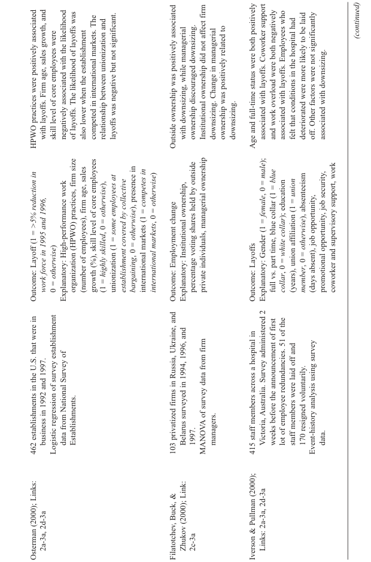

NOTE: figure/graphic rendered as an image from the PDF; its content is not machine-readable text. Caption (if any) follows as the next block.

**text found inside the figure**

Osterman (2000); Links:

2a-3a, 2d-3a

Filatotchev, Buck, &

Zhukov (2000); Link:

2c-3a

Iverson & Pullman (2000);

Links: 2a-3a, 2d-3a

462 establishments in the U.S. that were in business in 1992 and 1997.

Logistic regression of survey establishment

data from National Survey of

Establishments.

103 privatized firms in Russia, Ukraine, and Belarus surveyed in 1994, 1996, and

1997. MANOVA of survey data from firm

managers.

415 staff members across a hospital in Victoria, Australia. Survey administered 2

weeks before the announcement of first

lot of employee redundancies. 51 of the

staff members were laid off and

170 resigned voluntarily. Event-history analysis using survey

data.

Outcome: Layoff (1 = *>5% reduction in*

*work force in 1995 and 1996,*

0 *= otherwise*) Explanatory: High-performance work

organization (HPWO) practices, firm size

(number of employees), firm age, sales

growth (%), skill level of core employees

(1 = *highly skilled*, 0 = *otherwise*),

unionization (1 = *some employees at*

*establishment covered by collective*

*bargaining*, 0 = *otherwise*), presence in

international markets (1 = *competes in*

*international markets*, 0 = *otherwise*)

Outcome: Employment change

Explanatory: Institutional ownership,

percentage voting shares held by outside

private individuals, managerial ownership

Outcome: Layoffs

Explanatory: Gender (1 = *female*, 0 = *male*);

full vs. part time, blue collar (1 = *blue*

*collar*, 0 = *white collar*); education

(years), union affiliation (1 = *union*

*member*, 0 = *otherwise*), absenteeism

(days absent), job opportunity,

promotional opportunity, job security,

coworker and supervisory support, work

HPWO practices were positively associated

with layoffs. Firm age, sales growth, and

skill level of core employees were

negatively associated with the likelihood

of layoffs. The likelihood of layoffs was

also lower when the establishment

competed in international markets. The

relationship between unionization and

layoffs was negative but not significant.

Outside ownership was positively associated

with downsizing, while managerial

ownership discouraged downsizing.

Institutional ownership did not affect firm

downsizing. Change in managerial

ownership was positively related to

downsizing.

Age and full-time status were both positively

associated with layoffs. Coworker support

and work overload were both negatively

associated with layoffs. Employees who

felt that conditions in the hospital had

deteriorated were more likely to be laid

off. Other factors were not significantly

associated with downsizing.

*(continued)*

Page 18

298

**Table 2 (continued)**

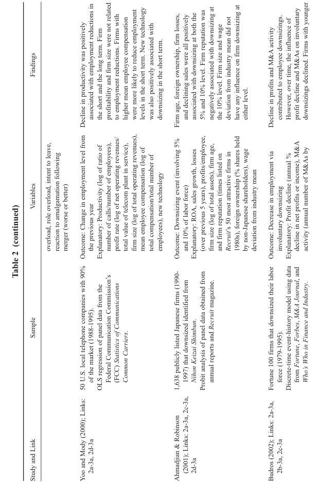

NOTE: figure/graphic rendered as an image from the PDF; its content is not machine-readable text. Caption (if any) follows as the next block.

**text found inside the figure**

Study and Link

Yoo and Mody (2000); Links:

2a-3a, 2d-3a

Ahmadjian & Robinson

(2001); Links: 2a-3a, 2c-3a,

2d-3a

Budros (2002); Links: 2a-3a,

2b-3a, 2c-3a

Sample

50 U.S. local telephone companies with 90% of the market (1988-1995).

OLS regression of panel data from the

Federal Communication Commission’s

(FCC) *Statistics of Communications*

*Common Carriers*.

1,638 publicly listed Japanese firms (1990- 1997) that downsized identified from *Nihon Keizai Shimbun*.

Probit analysis of panel data obtained from

annual reports and *Recruit* magazine.

Fortune 100 firms that downsized their labor

force (1979-1995).

Discrete-time event-history model using data

from *Fortune*, *Forbes*, *M&A Journal*, and

*Who’s Who in Finance and Industry*.

Variables

overload, role overload, intent to leave,

reaction to amalgamation following

merger (worse or better)

Outcome: Change in employment level from

the previous year

Explanatory: Productivity (log of ratio of

number of calls/number of employees),

profit rate (log of net operating revenues/

total value of telecom plant in service),

firm size (log of total operating revenues),

mean employee compensation (log of

total compensation/total number of

employees), new technology

Outcome: Downsizing event (involving 5%

and 10% of labor force)

Explanatory: ROA, sales growth, losses

(over previous 5 years), profits/employee,

firm size (log of total assets), firm age,

and firm reputation (times listed on

*Recruit*’s 50 most attractive firms in

1980s), foreign ownership (% shares held by non-Japanese shareholders), wage

deviation from industry mean

Outcome: Decrease in employment via

involuntary downsizing

Explanatory: Profit decline (annual %

decline in net profits or income), M&A

activity (annual number of M&As by

Findings

Decline in productivity was positively

associated with employment reductions in

the short and the long term. Firm

profitability and firm size were not related

to employment reductions. Firms with

higher mean employee compensation

were more likely to reduce employment

levels in the short term. New technology

was also positively associated with

downsizing in the short term.

Firm age, foreign ownership, firm losses,

and declining sales were all positively

associated with downsizing at both the

5% and 10% level. Firm reputation was negatively associated with downsizing at

the 10% level. Firm size and wage

deviation from industry mean did not

have any influence on firm downsizing at

either level.

Decline in profits and M&A activity

contributed to employee downsizings.

However, over time, the influence of

profit decline and M&As on involuntary

downsizings declined. Firms with younger

Page 19

299

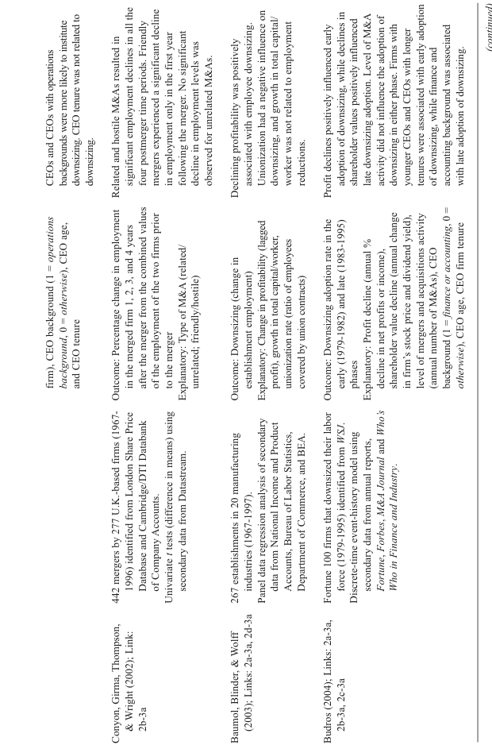

NOTE: figure/graphic rendered as an image from the PDF; its content is not machine-readable text. Caption (if any) follows as the next block.

**text found inside the figure**

Conyon, Girma, Thompson,

& Wright (2002); Link:

2b-3a

Baumol, Blinder, & Wolff

(2003); Links: 2a-3a, 2d-3a

Budros (2004); Links: 2a-3a,

2b-3a, 2c-3a

442 mergers by 277 U.K.-based firms (1967- 1996) identified from London Share Price Database and Cambridge/DTI Databank

of Company Accounts.

Univariate *t* tests (difference in means) using

secondary data from Datastream.

267 establishments in 20 manufacturing industries (1967-1997).

Panel data regression analysis of secondary

data from National Income and Product

Accounts, Bureau of Labor Statistics,

Department of Commerce, and BEA.

Fortune 100 firms that downsized their labor

force (1979-1995) identified from *WSJ*.

Discrete-time event-history model using

secondary data from annual reports,

*Fortune*, *Forbes*, *M&A Journal* and *Who’s*

*Who in Finance and Industry*.

firm), CEO background (1 = *operations*

*background*, 0 = *otherwise*), CEO age,

and CEO tenure

Outcome: Percentage change in employment

in the merged firm 1, 2, 3, and 4 years

after the merger from the combined values

of the employment of the two firms prior

to the merger

Explanatory: Type of M&A (related/

unrelated; friendly/hostile)

Outcome: Downsizing (change in

establishment employment)

Explanatory: Change in profitability (lagged

profit), growth in total capital/worker,

unionization rate (ratio of employees

covered by union contracts)

Outcome: Downsizing adoption rate in the

early (1979-1982) and late (1983-1995)

phases

Explanatory: Profit decline (annual %

decline in net profits or income),

shareholder value decline (annual change

in firm’s stock price and dividend yield),

level of mergers and acquisitions activity

(annual number of M&As), CEO

background (1 = *finance or accounting*, 0 =

*otherwise*), CEO age, CEO firm tenure

CEOs and CEOs with operations

backgrounds were more likely to institute

downsizing. CEO tenure was not related to

downsizing.

Related and hostile M&As resulted in

significant employment declines in all the

four postmerger time periods. Friendly

mergers experienced a significant decline

in employment only in the first year

following the merger. No significant

decline in employment levels was

observed for unrelated M&As.

Declining profitability was positively

associated with employee downsizing.

Unionization had a negative influence on

downsizing, and growth in total capital/

worker was not related to employment

reductions.

Profit declines positively influenced early

adoption of downsizing, while declines in

shareholder values positively influenced

late downsizing adoption. Level of M&A

activity did not influence the adoption of

downsizing in either phase. Firms with

younger CEOs and CEOs with longer

tenures were associated with early adoption

of downsizing, while finance and

accounting background was associated

with late adoption of downsizing.

*(continued)*

Page 20

300

**Table 2 (continued)**

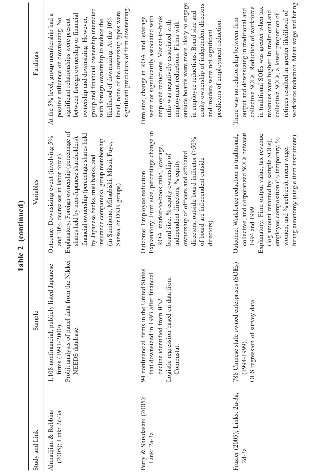

NOTE: figure/graphic rendered as an image from the PDF; its content is not machine-readable text. Caption (if any) follows as the next block.

**text found inside the figure**

Study and Link

Ahmadjian & Robbins

(2005); Link: 2c-3a

Perry & Shivdasani (2005);

Link: 2a-3a

Frazier (2005); Links: 2a-3a,

2d-3a

Sample

1,108 nonfinancial, publicly listed Japanese firms (1991-2000).

Probit analysis of panel data from the Nikkei

NEEDS database.

94 nonfinancial firms in the United States that downsized in 1993 after financial

decline identified from *WSJ*.

Logistic regression based on data from

Compustat.

788 Chinese state owned enterprises (SOEs) (1994-1999).

OLS regression of survey data.

Variables

Outcome: Downsizing event (involving 5%

and 10% decreases in labor force)

Explanatory: Foreign ownership (percentage of

shares held by non-Japanese shareholders),

financial ownership (percentage shares held

by Japanese banks, trust banks, and

insurance companies), group membership

(in Sumitomo, Mitsubishi, Mitsui, Fuyo,

Sanwa, or DKB groups)

Outcome: Employee reduction

Explanatory: Firm size, percentage change in

ROA, market-to-book ratio, leverage,

board size, % equity ownership of

independent directors, % equity

ownership of officers and affiliated

directors, outside board indicator (>50%

of board are independent outside

directors).

Outcome: Workforce reduction in traditional,

collective, and corporatized SOEs between

1994 and 1999 Explanatory: Firm output value, tax revenue

(log amount remitted by sample SOEs),

employee composition (% temporary, %

women, and % retirees), mean wage,

hiring autonomy (single item instrument)

Findings

At the 5% level, group membership had a

positive influence on downsizing. No

significant relationships were present

between foreign ownership or financial

ownership and downsizing. However,

group and financial ownership interacted

with foreign ownership to reduce the

likelihood of downsizing. At the 10%

level, none of the ownership types were

significant predictors of firm downsizing.

Firm size, change in ROA, and leverage

were not significantly associated with

employee reductions. Market-to-book

ratio was negatively associated with

employment reductions. Firms with

outside boards were more likely to engage

in employee reductions. Board size and

equity ownership of independent directors

and insiders were not significant

predictors of employment reduction.

There was no relationship between firm

output and downsizing in traditional and

collective SOEs. Reduction of workforce

in traditional SOEs was greater when tax

revenues were higher. In traditional and

collective SOEs, a lower proportion of

retirees resulted in greater likelihood of

workforce reduction. Mean wage and hiring

301

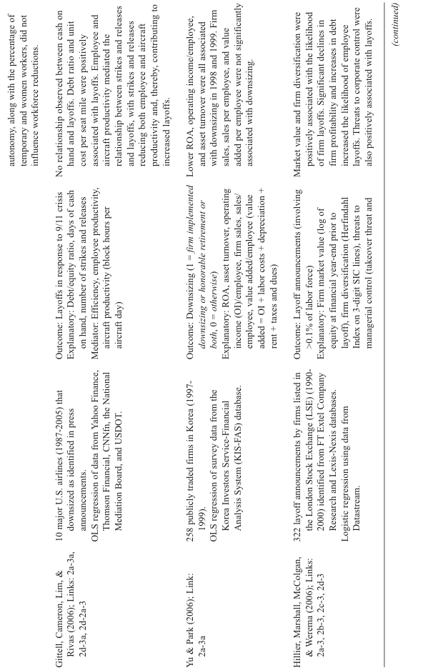

NOTE: figure/graphic rendered as an image from the PDF; its content is not machine-readable text. Caption (if any) follows as the next block.

**text found inside the figure**

Gittell, Cameron, Lim, &

Rivas (2006); Links: 2a-3a,

2d-3a, 2d-2a-3

Yu & Park (2006); Link:

2a-3a

Hillier, Marshall, McColgan,

& Werema (2006); Links:

2a-3, 2b-3, 2c-3, 2d-3

10 major U.S. airlines (1987-2005) that downsized as identified in press

announcements.

OLS regression of data from Yahoo Finance,

Thomson Financial, CNNfn, the National

Mediation Board, and USDOT.

258 publicly traded firms in Korea (1997- 1999). OLS regression of survey data from the

Korea Investors Service-Financial

Analysis System (KIS-FAS) database.

322 layoff announcements by firms listed in the London Stock Exchange (LSE) (1990-

2000) identified from FT Extel Company Research and Lexis-Nexis databases.

Logistic regression using data from

Datastream.

Outcome: Layoffs in response to 9/11 crisis

Explanatory: Debt/equity ratio, days of cash

on hand, number of strikes and releases

Mediator: Efficiency, employee productivity,

aircraft productivity (block hours per

aircraft day)

Outcome: Downsizing (1 = *firm implemented*

*downsizing or honorable retirement or*

*both*, 0 = *otherwise*)

Explanatory: ROA, asset turnover, operating

income (OI)/employee, firm sales, sales/

employee, value added/employee (value

added = OI + labor costs + depreciation +

rent + taxes and dues)

Outcome: Layoff announcements (involving

>0.1% of labor force)

Explanatory: Firm market value (log of

equity at financial year-end prior to

layoff), firm diversification (Herfindahl

Index on 3-digit SIC lines), threats to

managerial control (takeover threat and

autonomy, along with the percentage of

temporary and women workers, did not

influence workforce reductions.

No relationship observed between cash on

hand and layoffs. Debt ratio and unit

cost per seat mile were positively

associated with layoffs. Employee and

aircraft productivity mediated the

relationship between strikes and releases

and layoffs, with strikes and releases

reducing both employee and aircraft

productivity and, thereby, contributing to

increased layoffs.

Lower ROA, operating income/employee,

and asset turnover were all associated

with downsizing in 1998 and 1999. Firm

sales, sales per employee, and value

added per employee were not significantly

associated with downsizing.

Market value and firm diversification were

positively associated with the likelihood

of firm layoffs. Significant declines in

firm profitability and increases in debt

increased the likelihood of employee

layoffs. Threats to corporate control were

also positively associated with layoffs.

*(continued)*

302

**Table 2 (continued)**

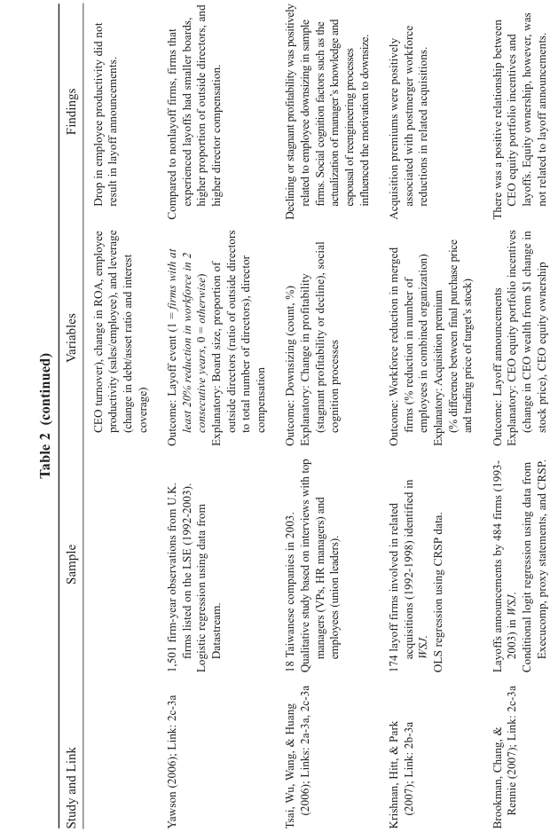

NOTE: figure/graphic rendered as an image from the PDF; its content is not machine-readable text. Caption (if any) follows as the next block.

**text found inside the figure**

Study and Link

Yawson (2006); Link: 2c-3a

Tsai, Wu, Wang, & Huang

(2006); Links: 2a-3a, 2c-3a

Krishnan, Hitt, & Park

(2007); Link: 2b-3a

Brookman, Chang, &

Rennie (2007); Link: 2c-3a

Sample

1,501 firm-year observations from U.K. firms listed on the LSE (1992-2003).

Logistic regression using data from

Datastream.

18 Taiwanese companies in 2003. Qualitative study based on interviews with top

managers (VPs, HR managers) and

employees (union leaders).

174 layoff firms involved in related acquisitions (1992-1998) identified in

*WSJ*.

OLS regression using CRSP data.

Layoffs announcements by 484 firms (1993-

2003) in *WSJ*. Conditional logit regression using data from

Execucomp, proxy statements, and CRSP.

Variables

CEO turnover), change in ROA, employee

productivity (sales/employee), and leverage

(change in debt/asset ratio and interest

coverage)

Outcome: Layoff event (1 = *firms with at*

*least 20% reduction in workforce in 2*

*consecutive years*, 0 = *otherwise*)

Explanatory: Board size, proportion of

outside directors (ratio of outside directors

to total number of directors), director

compensation

Outcome: Downsizing (count, %)

Explanatory: Change in profitability

(stagnant profitability or decline), social

cognition processes

Outcome: Workforce reduction in merged

firms (% reduction in number of

employees in combined organization)

Explanatory: Acquisition premium

(% difference between final purchase price

and trading price of target’s stock)

Outcome: Layoff announcements

Explanatory: CEO equity portfolio incentives

(change in CEO wealth from $1 change in

stock price), CEO equity ownership

Findings

Drop in employee productivity did not

result in layoff announcements.

Compared to nonlayoff firms, firms that

experienced layoffs had smaller boards,

higher proportion of outside directors, and

higher director compensation.

Declining or stagnant profitability was positively

related to employee downsizing in sample

firms. Social cognition factors such as the

actualization of manager’s knowledge and

espousal of reengineering processes

influenced the motivation to downsize.

Acquisition premiums were positively

associated with postmerger workforce

reductions in related acquisitions.

There was a positive relationship between

CEO equity portfolio incentives and

layoffs. Equity ownership, however, was

not related to layoff announcements.

303

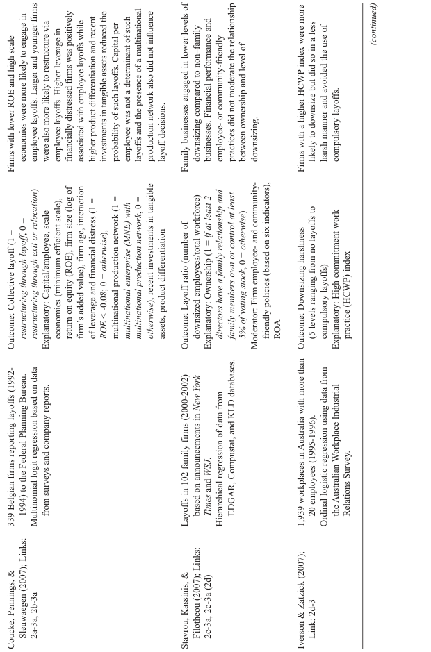

NOTE: figure/graphic rendered as an image from the PDF; its content is not machine-readable text. Caption (if any) follows as the next block.

**text found inside the figure**

Coucke, Pennings, &

Sleuwaegen (2007); Links:

2a-3a, 2b-3a

Stavrou, Kassinis, &

Filotheou (2007); Links:

2c-3a, 2c-3a (2d)

Iverson & Zatzick (2007);

Link: 2d-3

339 Belgian firms reporting layoffs (1992- 1994) to the Federal Planning Bureau. Multinomial logit regression based on data

from surveys and company reports.

Layoffs in 102 family firms (2000-2002)

based on announcements in *New York*

*Times* and *WSJ*.

Hierarchical regression of data from

EDGAR, Compustat, and KLD databases.

1,939 workplaces in Australia with more than 20 employees (1995-1996). Ordinal logistic regression using data from

the Australian Workplace Industrial

Relations Survey.

Outcome: Collective layoff (1 =

*restructuring through layoff*, 0 =

*restructuring through exit or relocation*)

Explanatory: Capital/employee, scale

economies (minimum efficient scale),

return on equity (ROE), firm size (log of

firm’s added value), firm age, interaction

of leverage and financial distress (1 =

*ROE* < -0.08; 0 = *otherwise*),

multinational production network (1 =

*multinational enterprise (MNE) with*

*multinational production network*, 0 =

*otherwise*), recent investments in tangible

assets, product differentiation

Outcome: Layoff ratio (number of

downsized employees/total workforce)

Explanatory: Ownership (1 = *if at least 2*

*directors have a family relationship and*

*family members own or control at least*

*5% of voting stock*, 0 = *otherwise*) Moderator: Firm employee- and community-

friendly policies (based on six indicators),

ROA

Outcome: Downsizing harshness

(5 levels ranging from no layoffs to

compulsory layoffs)

Explanatory: High commitment work

practice (HCWP) index

Firms with lower ROE and high scale

economies were more likely to engage in

employee layoffs. Larger and younger firms

were also more likely to restructure via

employee layoffs. Higher leverage in

financially distressed firms was positively

associated with employee layoffs while

higher product differentiation and recent

investments in tangible assets reduced the

probability of such layoffs. Capital per

employee was not a determinant of such

layoffs and the presence of a multinational

production network also did not influence

layoff decisions.

Family businesses engaged in lower levels of

downsizing compared to non–family

businesses. Financial performance and

employee- or community-friendly

practices did not moderate the relationship

between ownership and level of

downsizing.

Firms with a higher HCWP index were more

likely to downsize but did so in a less

harsh manner and avoided the use of

compulsory layoffs.

*(continued)*

304

**Table 2 (continued)**

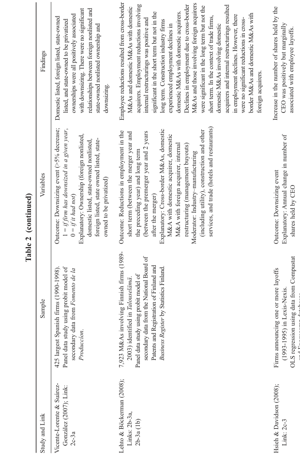

NOTE: figure/graphic rendered as an image from the PDF; its content is not machine-readable text. Caption (if any) follows as the next block.

**text found inside the figure**

Study and Link

Vicente-Lorente & Suárez-

González (2007); Link:

2c-3a

Lehto & Böckerman (2008);

Links: 2b-3a,

2b-3a (1b)

Hsieh & Davidson (2008);

Link: 2c-3

Sample

425 largest Spanish firms (1990-1998). Panel data study using probit model of

secondary data from *Fomento de la*

*Produccíon*.

7,923 M&As involving Finnish firms (1989- 2003) identified in *Talouselämä*. Panel data study using probit model of

secondary data from the National Board of

Patents and Registration of Finland and

*Business Register* by Statistics Finland.

Firms announcing one or more layoffs

(1993-1995) in Lexis-Nexis.

OLS regression using data from Compustat

Variables

Outcome: Downsizing event (>5% decrease;

1 = *if firm has downsized in a given year*, 0 = *if it had not*) Explanatory: Ownership (foreign nonlisted,

domestic listed, state-owned nonlisted,

foreign listed, state owned listed, state-

owned to be privatized)

Outcome: Reductions in employment in the

short term (between the merger year and

the preceding year) and long term

(between the premerger year and 2 years

after the merger)

Explanatory: Cross-border M&As, domestic

M&A with domestic acquirer, domestic

M&A with foreign acquirer, internal

restructuring (management buyouts)

Moderator: Industry–manufacturing

(including utility), construction and other

services, and trade (hotels and restaurants)

Outcome: Downsizing event

Explanatory: Annual change in number of

shares held by CEO

Findings

Domestic listed, foreign listed, state-owned

listed, and state-owned to be privatized

ownerships were all positively associated

with downsizing. There were no significant

relationships between foreign nonlisted and

state-owned nonlisted ownership and

downsizing.

Employee reductions resulted from cross-border

M&As and domestic M&As with domestic

acquirers. Employment reductions involving

internal restructurings was positive and

significant in the short term but not in the

long term. Construction industry firms

experienced employment declines in

domestic M&As with domestic acquirers.

Declines in employment due to cross-border

M&As and those involving foreign acquirers

were significant in the long term but not the

short term. In the context of trade firms,

domestic M&As involving domestic

acquirers and internal restructurings resulted

in employment declines. However, there

were no significant reductions in cross-

border M&As and domestic M&As with

foreign acquirers.

Increase in the number of shares held by the

CEO was positively but marginally

associated with employee layoffs.

and Execucomp databases.

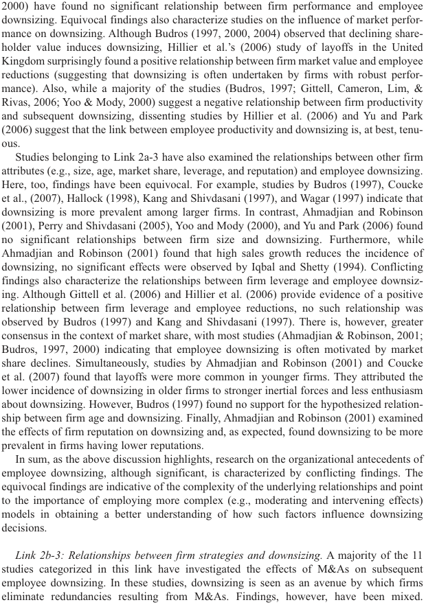

NOTE: figure/graphic rendered as an image from the PDF; its content is not machine-readable text. Caption (if any) follows as the next block.

**text found inside the figure**

2000) have found no significant relationship between firm performance and employee downsizing. Equivocal findings also characterize studies on the influence of market performance on downsizing. Although Budros (1997, 2000, 2004) observed that declining shareholder value induces downsizing, Hillier et al.’s (2006) study of layoffs in the United Kingdom surprisingly found a positive relationship between firm market value and employee reductions (suggesting that downsizing is often undertaken by firms with robust performance). Also, while a majority of the studies (Budros, 1997; Gittell, Cameron, Lim, & Rivas, 2006; Yoo & Mody, 2000) suggest a negative relationship between firm productivity and subsequent downsizing, dissenting studies by Hillier et al. (2006) and Yu and Park (2006) suggest that the link between employee productivity and downsizing is, at best, tenuous.

Studies belonging to Link 2a-3 have also examined the relationships between other firm attributes (e.g., size, age, market share, leverage, and reputation) and employee downsizing. Here, too, findings have been equivocal. For example, studies by Budros (1997), Coucke et al., (2007), Hallock (1998), Kang and Shivdasani (1997), and Wagar (1997) indicate that downsizing is more prevalent among larger firms. In contrast, Ahmadjian and Robinson (2001), Perry and Shivdasani (2005), Yoo and Mody (2000), and Yu and Park (2006) found no significant relationships between firm size and downsizing. Furthermore, while Ahmadjian and Robinson (2001) found that high sales growth reduces the incidence of downsizing, no significant effects were observed by Iqbal and Shetty (1994). Conflicting findings also characterize the relationships between firm leverage and employee downsizing. Although Gittell et al. (2006) and Hillier et al. (2006) provide evidence of a positive relationship between firm leverage and employee reductions, no such relationship was observed by Budros (1997) and Kang and Shivdasani (1997). There is, however, greater consensus in the context of market share, with most studies (Ahmadjian & Robinson, 2001; Budros, 1997, 2000) indicating that employee downsizing is often motivated by market share declines. Simultaneously, studies by Ahmadjian and Robinson (2001) and Coucke et al. (2007) found that layoffs were more common in younger firms. They attributed the lower incidence of downsizing in older firms to stronger inertial forces and less enthusiasm about downsizing. However, Budros (1997) found no support for the hypothesized relationship between firm age and downsizing. Finally, Ahmadjian and Robinson (2001) examined the effects of firm reputation on downsizing and, as expected, found downsizing to be more prevalent in firms having lower reputations.

In sum, as the above discussion highlights, research on the organizational antecedents of employee downsizing, although significant, is characterized by conflicting findings. The equivocal findings are indicative of the complexity of the underlying relationships and point to the importance of employing more complex (e.g., moderating and intervening effects) models in obtaining a better understanding of how such factors influence downsizing decisions.

*Link 2b-3: Relationships between firm strategies and downsizing.* A majority of the 11 studies categorized in this link have investigated the effects of M&As on subsequent employee downsizing. In these studies, downsizing is seen as an avenue by which firms eliminate redundancies resulting from M&As. Findings, however, have been mixed.

Specifically, whereas Budros (2002), Conyon, Girma, Thompson, and Wright (2002), and Lehto and Bockerman (2008) observed significant employment declines following M&As, studies by Budros (1997, 2004), and Wagar (1997) did not. In examining the relationship between M&As and downsizing, O’Shaughnessy and Flanagan (1998) observed that the relationship between the two was contingent on M&A type, with the likelihood of employee reductions being greater in the context of related transactions. Their findings were corroborated by Conyon et al. (2004). In addition, Conyon et al. (2004) found that hostile mergers were more likely to be accompanied by significant postmerger employment reductions than friendly transactions. Budros (2000) examined the moderating effects of industry type and found that downsizing was more likely in mergers undertaken in the manufacturing rather than the financial or utility sectors. Finally, in a study involving the effects of acquisition premiums, Krishnan, Hitt, and Park (2007) found that when acquiring firms paid higher acquisition premiums to target firm shareholders, it typically led to greater workforce reductions in the postacquisition phase.

Surprisingly, very limited research exists on the relationships between firm strategies (at the corporate or business level) and employee downsizing. Exceptions include relatively recent studies by Hillier et al. (2006) and Coucke et al. (2007), with the former concluding that the incidence of layoffs was higher among more diversified firms. Coucke et al. (2007), on the other hand, used a sample of Belgian firms to study the effects of competitive positioning on collective employee layoffs. They found that firms that emphasized product differentiation were less likely to engage in employee downsizing.

*Link 2c-3: Relationships between firm governance, CEO characteristics, and downsizing.* Studies belonging to this link have primarily used agency theory arguments in assessing the effects of governance mechanisms (board characteristics, ownership structures, and compensation systems) on employee downsizing. In an early attempt at understanding the relationships between ownership structures and downsizing, Bethel and Liebeskind (1993) found that firms with greater blockholder ownership experienced higher levels of employee reductions. In contrast, Filatotchev et al. (2000), in their study of layoffs among firms in Russia, Ukraine, and Belarus, observed no relationship between institutional ownership and downsizing. However, their study did indicate that although outside private ownership results in higher levels of employee downsizing, greater managerial ownership has the opposite effect. Similarly, a study by Stavrou, Kassinis, and Filotheou (2007) revealed that firms with high levels of family ownership engaged in less severe downsizing. Finally, in their assessment of the effects of foreign ownership on downsizing in Japanese firms, Ahmadjian and Robinson (2001) found that although such ownership resulted in increased likelihood of employee downsizing in a broad cross-section of firms, it was not so among nonfinancial firms. Research on the role of governance in the context of downsizing has also examined the role of board independence and board size in downsizing decisions. Findings suggest that firms with independent boards (i.e., a greater proportion of independent directors) are more likely to engage in downsizing (Perry & Shivdasani, 2005). However, unlike Perry and Shivdasani (2005), who found no significant relationship between board size and downsizing, Yawson (2006) observed that the propensity to downsize is lower among firms with larger boards.

A few studies in this link have focused on the effects of CEO demographic characteristics on downsizing decisions. In examining the role of CEO functional background, Budros (2000, 2002, 2004) found that the incidence of downsizing was higher in firms that had CEOs with a finance or operations background. However, this relationship was contingent on industry type, with a finance background being associated with downsizing only in the context of firms in the financial sector (but not the industrial or utility sectors). In addition, Budros (2002, 2004) observed a negative relationship between CEO age and downsizing, although this relationship was prevalent only among early adopters of downsizing. In contrast, Hallock (1998) found that neither CEO age nor tenure had any effect on the adoption of employee downsizing.

*Link 2d-3: Relationships between HR practices, employee attributes, and downsizing.* Most studies belonging to this link have explored the effects of firms’ HR policies and practices on employee downsizing. Not surprisingly, Wagar (1997) found that when firms are more committed to employee job security, the likelihood of employee layoffs is diminished. However, he found no significant relationships between employee unionization and downsizing. In contrast, studies by Baumol et al. (2003) and Redman and Keithley (1998) provide evidence of a negative relationship between union density and employee downsizing. In addition, although it has been hypothesized that the level of employee compensation influences downsizing, a majority of the studies (Budros, 1997, 2000, 2001; Frazier, 2005; Iqbal & Shetty, 1994) indicate that employee compensation has no bearing on the extent or likelihood of employee downsizing. However, Yoo and Mody (2000), in their study of 50 U.S. local telephone companies, did find a positive relationship between mean employee compensation and the level of downsizing.

More recently, scholars have examined the effects of high commitment work practices (HCWP) on workforce reductions. Consistent with Osterman (2000), Iverson and Zatzick (2007) found that firms that make greater use of HCWP are more likely to engage in workforce downsizing. Their explanation for this finding is that in these workplaces, the use of HCWP tends to be part of a more general movement toward increased efficiency and productivity. Moreover, the use of these HR practices leads to a more competent, committed workforce and an ability to use leaner staffing. However, Iverson and Zatzick (2007: 471) also created a measure of downsizing “harshness” and found that greater use of high- commitment HR practices is associated with less harsh downsizing practices: “more HCWP is related to the use of downsizing, but it is through the use of more employee friendly strategies of voluntary layoffs and alternative strategies.”

### *Stream III: Individual Outcomes of Employee Downsizing*

Stream III research relates to the consequences of downsizing from the standpoint of employee attitude and behaviors. Downsizing has a significant potential to affect group and individual attitudes and behavior, disrupt relationship networks, and destroy the trust and loyalty that binds employees and their employers. The literature on organizational change (especially in the context of a significant event such as employee downsizing) suggests that

the consequence of change largely depends on how well the change process is managed. For example, it has been argued that effective communication, characterized by helpfulness (Miller & Monge, 1985), openness (Miller, Johnson, & Grau, 1994), and accuracy, timing, and completeness (Richardson & Denton, 1996), can help mitigate anxiety and reduce the resistance to change among downsizing survivors. Likewise, the change management literature recommends that the procedures used to manage change allow for employee inputs into the design of changes by providing them with opportunities to express their views and appeal decisions (Self et al., 2007). Enabling employees to maintain a sense of control should result in increased acceptance and commitment to the change (Cummings & Worley, 1993).

The influence of downsizing on individuals and groups in an organization has been examined in the context of psychological contract theory, which emphasizes the negative implications of violating implicit contracts governing relationships between firms and employees (Rousseau & Tijoriwala, 1998). Psychological contracts refer to perceptions about a set of mutual obligations that link employers and employees. They are based on expectations that each party will fulfill its obligation in accordance with their implicit contracts. The “contract” suggested in the downsizing literature is an expectation on the part of employees that their contributions to the workplace will be reciprocated with a stable and positive work environment. As such, downsizing is often perceived as a violation of the psychological contract (De Meuse, Bergmann, Vanderheiden, & Roraff, 2004; Morrison & Robinson, 1997; Rousseau, 1995) by survivors and victims alike. Given that contracts are fundamental to employees’ beliefs and experiences, violations of such contracts have important consequences for employees’ work attitudes and behaviors (Robinson, 1996). Surviving employees may withdraw psychologically (e.g., reduced trust and loyalty, withholding of effort, and reduced involvement) or physically (increased absences or voluntary turnover), with negative economic consequences for the firm.

Individual outcomes associated with downsizing have also been explained using justice theories, the basic tenet of which is that individuals evaluate situations with potentially important implications for them and react favorably if they perceive the situation to be “fair.” Early work on distributive justice drew on equity theory to propose that individuals compare the ratio of their inputs and outcomes with those of relevant others to determine the fairness of their outcomes. Procedural justice (Thibault & Walker, 1975), on the other hand, concerns itself with the fairness of processes used in arriving at decisions in the allocation of resources (Hegtvedt & Markovsky, 1995). Processes are viewed as being fair when they provide for consistency across individuals and time, are free of bias, incorporate and reflect the opinions of people affected, and conform to moral and ethical standards (Leventhal, Karuza, & Fry, 1980). In the context of downsizing, perceptions of fairness related to downsizing decisionmaking and implementation processes have a significant bearing on subsequent behavior. Justice perceptions are influenced by employees’ perceptions on whether layoffs were necessary, the appropriateness of the decision criteria used in identifying redundancies, and whether victims were fairly treated and adequately provided for after being downsized (Shah, 2000). If these are all deemed to be “fair” and “just,” this evaluation can counteract and significantly offset the disappointment of downsizing. Conversely, perceptions of procedural *in*justice and *un*fairness are likely to magnify negative reactions and be manifested in reduced employee commitment and undesired behavioral outcomes.

The 26 studies in Stream III can be categorized into four groups based on the effects of downsizing on (a) job involvement, organizational commitment, loyalty, job satisfaction, and self-esteem (Link 3-4a with 20 studies); (b) trust, perceptions of justice, work conflict, and workplace environment (Link 3-4b with 10 studies); (c) voluntary turnover intent and absenteeism (Link 3-4c with 5 studies); and (d) work performance (Link 3-4d with 7 studies). Table 3 provides a summary of the empirical studies belonging to this stream.

*Link 3-4a: Relationships between downsizing and job involvement, job satisfaction, loyalty, and self-esteem.* Downsizing can have a profound impact on employee attitudes and behaviors, and these have been explored in the empirical literature associated with Link 3-4a. Although there is general agreement that downsizing results in lower job involvement and reduced organizational commitment among survivors (Allen, Freeman, Russell, Reizenstein, & Rentz, 2001; Brockner et al., 2004; Luthans & Sommer, 1999; Travaglione & Cross, 2006), studies by Armstrong-Stassen (1994) and Brockner et al. (2004) suggest that the effects are mitigated when downsizing is accompanied by high supervisor support and greater perceived control. Armstrong-Stassen’s (1994) findings also suggest that job commitment following downsizing is a function of the coping strategy adopted by survivors with control coping (based on proactive goal setting and development of plans) resulting in greater commitment among survivors and escape coping (denial and distancing) having the opposite effect.

In addition to the above, studies by Spreitzer and Mishra (2002) and Chang (2002) indicate that negative effects of downsizing on the attachment and commitment of survivors is mitigated by management trustworthiness and perceptions of distributive justice (fairness of outcomes from downsizing). Spreitzer and Mishra’s (2002) study also highlights the role of empowerment in increasing organizational attachment among downsizing survivors. On the other hand, they observed that low procedural justice led to significant reductions in selfesteem, especially among survivors with high organizational commitment.

Finally, Link 3-4a studies also indicate that downsizing results in reduced organizational commitment and job satisfaction (Gilson, Hurd, & Wagar, 2004; Luthans & Sommer, 1999; Travaglione & Cross, 2006). However, research by Allen et al. (2001) and Armstrong- Stassen (2002) suggests that adverse effects are relatively short-lived and diminish with time.

*Link 3-4b: Relationships between downsizing, perceptions of trust and justice, and work environment changes.* The limited research belonging to this link explores the effects of downsizing on organizational trust, perceived justice, workplace conflict, and changes in the work environment. The role of perceived justice in the context of downsizing was first highlighted by Brockner et al. (1994). They found that layoff severity did not have a perceptible impact on organizational trust and support when survivors perceived high procedural fairness. However, under conditions of low perceived procedural fairness, layoff severity had a significant deleterious effect on organizational trust. In a subsequent study, Mansour-Cole and Scott (1998) found that survivors perceive greater procedural fairness when they learn about impending layoffs from their managers and not from other sources. They also found that the relationship between the source of layoff information and perceived procedural

*(Text continues on p. 321)*

310

**Table 3**

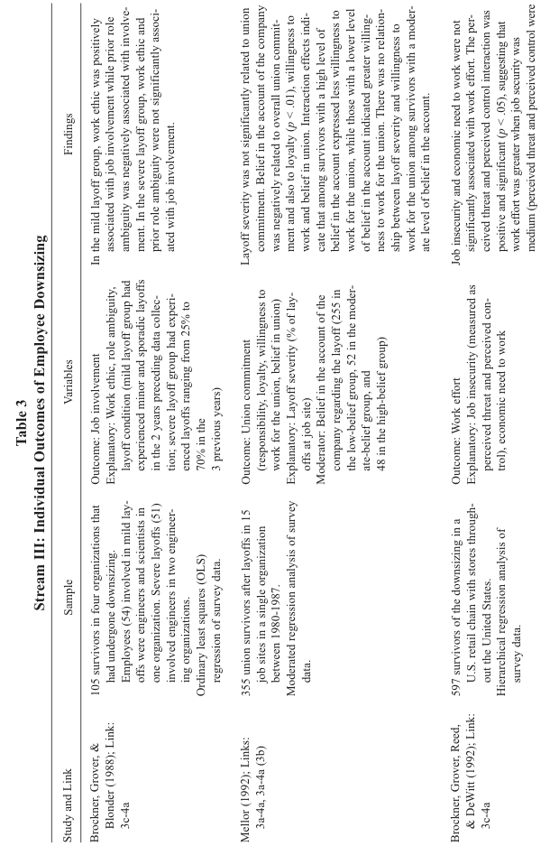

NOTE: figure/graphic rendered as an image from the PDF; its content is not machine-readable text. Caption (if any) follows as the next block.

**text found inside the figure**

**Stream III: Individual Outcomes of Employee Downsizing**

Study and Link

Brockner, Grover, &

Blonder (1988); Link:

3c-4a

Mellor (1992); Links:

3a-4a, 3a-4a (3b)

Brockner, Grover, Reed,

& DeWitt (1992); Link:

3c-4a

Sample

105 survivors in four organizations that had undergone downsizing.

Employees (54) involved in mild lay-

offs were engineers and scientists in

one organization. Severe layoffs (51)

involved engineers in two engineer-

ing organizations.

Ordinary least squares (OLS)

regression of survey data.

355 union survivors after layoffs in 15 job sites in a single organization

between 1980-1987.

Moderated regression analysis of survey

data.

597 survivors of the downsizing in a U.S. retail chain with stores through-

out the United States.

Hierarchical regression analysis of

survey data.

Variables

Outcome: Job involvement

Explanatory: Work ethic, role ambiguity,

layoff condition (mild layoff group had

experienced minor and sporadic layoffs

in the 2 years preceding data collec-

tion; severe layoff group had experi-

enced layoffs ranging from 25% to

70% in the 3 previous years)

Outcome: Union commitment

(responsibility, loyalty, willingness to

work for the union, belief in union)

Explanatory: Layoff severity (% of lay-

offs at job site)

Moderator: Belief in the account of the

company regarding the layoff (255 in

the low-belief group, 52 in the moder-

ate-belief group, and

48 in the high-belief group)

Outcome: Work effort

Explanatory: Job insecurity (measured as

perceived threat and perceived con-

trol), economic need to work

Findings

In the mild layoff group, work ethic was positively

associated with job involvement while prior role

ambiguity was negatively associated with involve-

ment. In the severe layoff group, work ethic and

prior role ambiguity were not significantly associ-

ated with job involvement.

Layoff severity was not significantly related to union

commitment. Belief in the account of the company

was negatively related to overall union commit-

ment and also to loyalty (*p* < .01), willingness to

work and belief in union. Interaction effects indi-

cate that among survivors with a high level of

belief in the account expressed less willingness to

work for the union, while those with a lower level

of belief in the account indicated greater willing-

ness to work for the union. There was no relation-

ship between layoff severity and willingness to

work for the union among survivors with a moder-

ate level of belief in the account.

Job insecurity and economic need to work were not

significantly associated with work effort. The per-

ceived threat and perceived control interaction was

positive and significant (*p* < .05), suggesting that

work effort was greater when job security was

medium (perceived threat and perceived control were

311

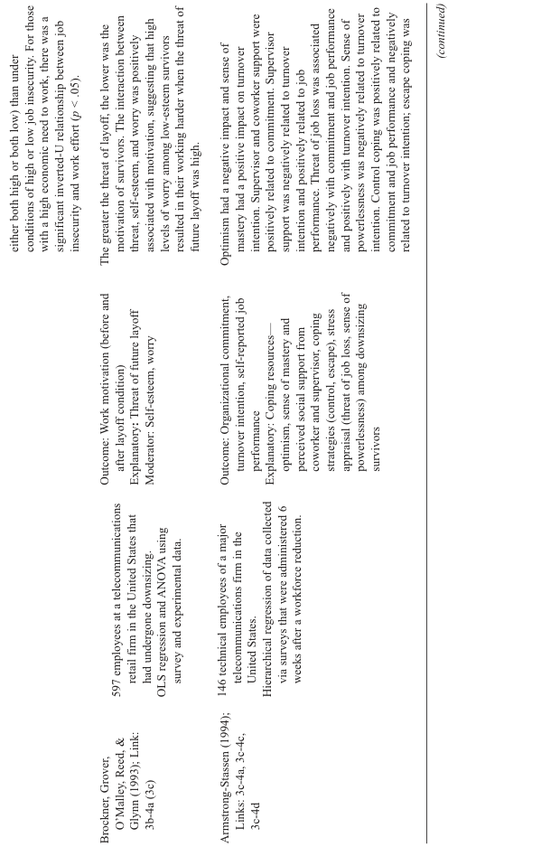

NOTE: figure/graphic rendered as an image from the PDF; its content is not machine-readable text. Caption (if any) follows as the next block.

**text found inside the figure**

Brockner, Grover,

O’Malley, Reed, &

Glynn (1993); Link:

3b-4a (3c)

Armstrong-Stassen (1994);

Links: 3c-4a, 3c-4c,

3c-4d

597 employees at a telecommunications retail firm in the United States that

had undergone downsizing.

OLS regression and ANOVA using

survey and experimental data.

146 technical employees of a major telecommunications firm in the

United States.

Hierarchical regression of data collected

via surveys that were administered 6

weeks after a workforce reduction.

Outcome: Work motivation (before and

after layoff condition)

Explanatory**:** Threat of future layoff

Moderator: Self-esteem, worry

Outcome: Organizational commitment,

turnover intention, self-reported job

performance

Explanatory: Coping resources—

optimism, sense of mastery and

perceived social support from

coworker and supervisor, coping

strategies (control, escape), stress

appraisal (threat of job loss, sense of

powerlessness) among downsizing

survivors

either both high or both low) than under

conditions of high or low job insecurity. For those

with a high economic need to work, there was a

significant inverted-U relationship between job

insecurity and work effort (*p* < .05).

The greater the threat of layoff, the lower was the

motivation of survivors. The interaction between

threat, self-esteem, and worry was positively

associated with motivation, suggesting that high

levels of worry among low-esteem survivors

resulted in their working harder when the threat of

future layoff was high.

Optimism had a negative impact and sense of

mastery had a positive impact on turnover

intention. Supervisor and coworker support were

positively related to commitment. Supervisor

support was negatively related to turnover

intention and positively related to job

performance. Threat of job loss was associated

negatively with commitment and job performance

and positively with turnover intention. Sense of

powerlessness was negatively related to turnover

intention. Control coping was positively related to

commitment and job performance and negatively

related to turnover intention; escape coping was

*(continued)*

312

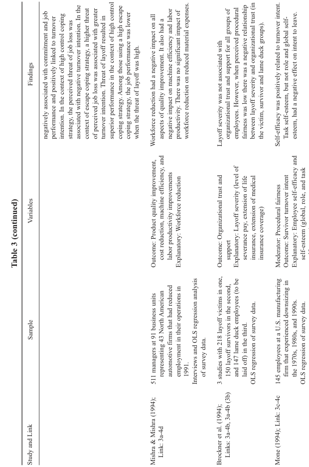

NOTE: figure/graphic rendered as an image from the PDF; its content is not machine-readable text. Caption (if any) follows as the next block.

**text found inside the figure**

Study and Link

Mishra & Mishra (1994);

Link: 3a-4d

Brockner et al. (1994);

Links: 3a-4b, 3a-4b (3b)

Mone (1994); Link: 3c-4c

Sample

511 managers at 91 business units representing 43 North American

automotive firms that had reduced

employment in their operations in

1991. Interviews and OLS regression analysis

of survey data.

3 studies with 218 layoff victims in one, 150 layoff survivors in the second, and 147 lame duck employees (to be

laid off) in the third.

OLS regression of survey data.

145 employees at a U.S. manufacturing firm that experienced downsizing in

the 1970s, 1980s, and 1990s.

OLS regression of survey data.

Variables

Outcome: Product quality improvement,

cost reduction, machine efficiency, and

labor productivity improvements

Explanatory: Workforce reduction

Outcome: Organizational trust and

support

Explanatory: Layoff severity (level of

severance pay, extension of life

insurance, extension of medical

insurance coverage)

Moderator: Procedural fairness

Outcome: Survivor turnover intent

Explanatory: Employee self-efficacy and

self-esteem (global, role, and task

Findings

negatively associated with commitment and job

performance and positively linked to turnover

intention. In the context of high control coping

strategy, the perceived threat of job loss was

associated with negative turnover intention. In the

context of escape coping strategy, a higher threat

of perceived job loss was associated with greater

turnover intention. Threat of layoff resulted in

superior performance in the context of high control

coping strategy. Among those using a high escape

coping strategy, the job performance was lower

when the threat of layoff was high.

Workforce reduction had a negative impact on all

aspects of quality improvement. It also had a

negative impact on machine efficiency and labor

productivity. There was no significant impact of

workforce reduction on reduced material expenses.

Layoff severity was not associated with

organizational trust and support for all groups of

employees. However, when perceived procedural

fairness was low there was a negative relationship

between layoff severity and organizational trust (in

the victim, survivor and lame duck groups).

Self-efficacy was positively related to turnover intent.

Task self-esteem, but not role and global self-

esteem, had a negative effect on intent to leave.

self-esteem)

**Table 3 (continued)**

313

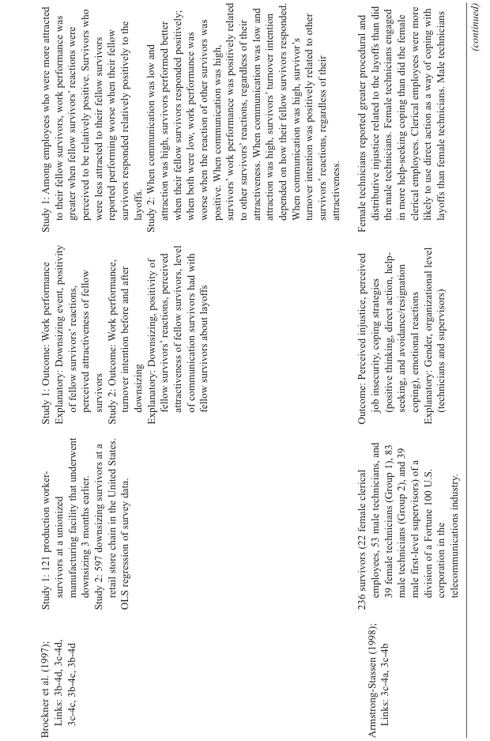

NOTE: figure/graphic rendered as an image from the PDF; its content is not machine-readable text. Caption (if any) follows as the next block.

**text found inside the figure**

Brockner et al. (1997);

Links: 3b-4d, 3c-4d,

3c-4c, 3b-4c, 3b-4d

Armstrong-Stassen (1998);

Links: 3c-4a, 3c-4b

Study 1: 121 production worker-

survivors at a unionized

manufacturing facility that underwent

downsizing 3 months earlier.

Study 2: 597 downsizing survivors at a

retail store chain in the United States.

OLS regression of survey data.

236 survivors (22 female clerical employees, 53 male technicians, and

39 female technicians (Group 1), 83 male technicians (Group 2), and 39

male first-level supervisors) of a

division of a Fortune 100 U.S.

corporation in the

telecommunications industry.

Study 1: Outcome: Work performance

Explanatory: Downsizing event, positivity

of fellow survivors’ reactions,

perceived attractiveness of fellow

survivors

Study 2: Outcome: Work performance,

turnover intention before and after

downsizing

Explanatory: Downsizing, positivity of

fellow survivors’ reactions, perceived

attractiveness of fellow survivors, level

of communication survivors had with

fellow survivors about layoffs

Outcome: Perceived injustice, perceived

job insecurity, coping strategies

(positive thinking, direct action, help-

seeking, and avoidance/resignation

coping), emotional reactions

Explanatory: Gender, organizational level

(technicians and supervisors)

Study 1: Among employees who were more attracted

to their fellow survivors, work performance was

greater when fellow survivors’ reactions were

perceived to be relatively positive. Survivors who

were less attracted to their fellow survivors

reported performing worse when their fellow

survivors responded relatively positively to the

layoffs.

Study 2: When communication was low and

attraction was high, survivors performed better

when their fellow survivors responded positively;

when both were low, work performance was

worse when the reaction of other survivors was

positive. When communication was high,

survivors’ work performance was positively related

to other survivors’ reactions, regardless of their

attractiveness. When communication was low and

attraction was high, survivors’ turnover intention

depended on how their fellow survivors responded.

When communication was high, survivor’s

turnover intention was positively related to other

survivors’ reactions, regardless of their

attractiveness.

Female technicians reported greater procedural and

distributive injustice related to the layoffs than did

the male technicians. Female technicians engaged

in more help-seeking coping than did the female

clerical employees. Clerical employees were more

likely to use direct action as a way of coping with

layoffs than female technicians. Male technicians

*(continued)*

314

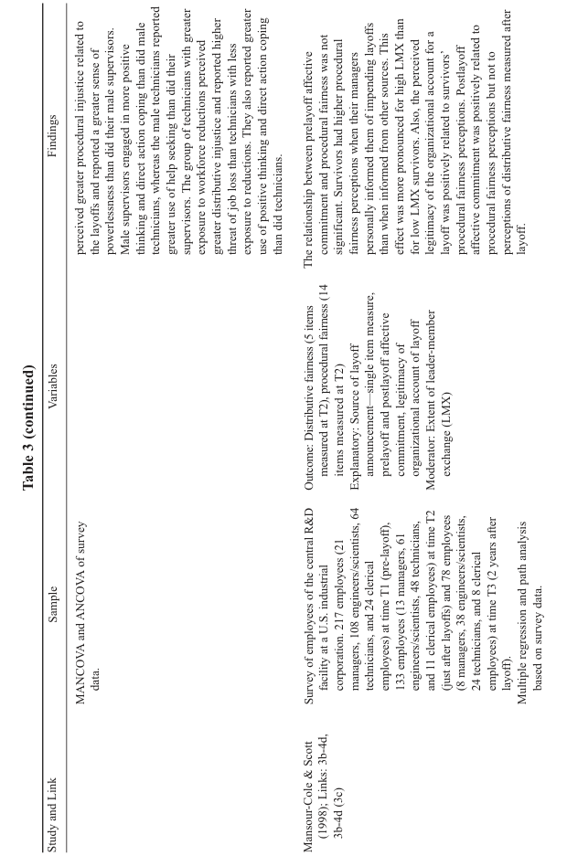

NOTE: figure/graphic rendered as an image from the PDF; its content is not machine-readable text. Caption (if any) follows as the next block.

**text found inside the figure**

Study and Link

Mansour-Cole & Scott

(1998); Links: 3b-4d,

3b-4d (3c)

Sample

MANCOVA and ANCOVA of survey

data.

Survey of employees of the central R&D

facility at a U.S. industrial

corporation. 217 employees (21

managers, 108 engineers/scientists, 64

technicians, and 24 clerical

employees) at time T1 (pre-layoff),

133 employees (13 managers, 61 engineers/scientists, 48 technicians,

and 11 clerical employees) at time T2

(just after layoffs) and 78 employees

(8 managers, 38 engineers/scientists,

24 technicians, and 8 clerical employees) at time T3 (2 years after

layoff).

Multiple regression and path analysis

based on survey data.

Variables

Outcome: Distributive fairness (5 items

measured at T2), procedural fairness (14

items measured at T2)

Explanatory: Source of layoff

announcement—single item measure,

prelayoff and postlayoff affective

commitment, legitimacy of

organizational account of layoff

Moderator: Extent of leader-member

exchange (LMX)

Findings

perceived greater procedural injustice related to

the layoffs and reported a greater sense of

powerlessness than did their male supervisors.

Male supervisors engaged in more positive

thinking and direct action coping than did male

technicians, whereas the male technicians reported

greater use of help seeking than did their

supervisors. The group of technicians with greater

exposure to workforce reductions perceived

greater distributive injustice and reported higher

threat of job loss than technicians with less

exposure to reductions. They also reported greater

use of positive thinking and direct action coping

than did technicians.

The relationship between prelayoff affective

commitment and procedural fairness was not

significant. Survivors had higher procedural

fairness perceptions when their managers

personally informed them of impending layoffs

than when informed from other sources. This

effect was more pronounced for high LMX than

for low LMX survivors. Also, the perceived

legitimacy of the organizational account for a

layoff was positively related to survivors’

procedural fairness perceptions. Postlayoff

affective commitment was positively related to

procedural fairness perceptions but not to

perceptions of distributive fairness measured after

layoff.

**Table 3 (continued)**

315

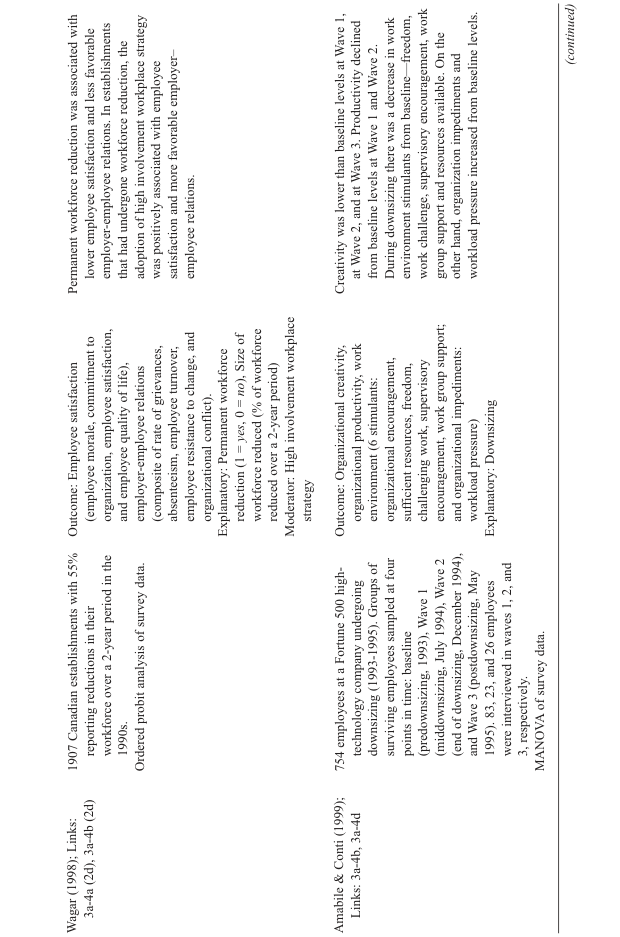

NOTE: figure/graphic rendered as an image from the PDF; its content is not machine-readable text. Caption (if any) follows as the next block.

**text found inside the figure**

Wagar (1998); Links:

3a-4a (2d), 3a-4b (2d)

Amabile & Conti (1999);

Links: 3a-4b, 3a-4d

1907 Canadian establishments with 55% reporting reductions in their

workforce over a 2-year period in the

1990s. Ordered probit analysis of survey data.

754 employees at a Fortune 500 hightechnology company undergoing

downsizing (1993-1995). Groups of

surviving employees sampled at four

points in time: baseline

(predownsizing, 1993), Wave 1

(middownsizing, July 1994), Wave 2

(end of downsizing, December 1994),

and Wave 3 (postdownsizing, May

1995). 83, 23, and 26 employees were interviewed in waves 1, 2, and

3, respectively. MANOVA of survey data.

Outcome: Employee satisfaction

(employee morale, commitment to

organization, employee satisfaction,

and employee quality of life),

employer-employee relations

(composite of rate of grievances,

absenteeism, employee turnover,

employee resistance to change, and

organizational conflict).

Explanatory: Permanent workforce

reduction (1 = *yes*, 0 = *no*), Size of

workforce reduced (% of workforce

reduced over a 2-year period)

Moderator: High involvement workplace

strategy

Outcome: Organizational creativity,

organizational productivity, work

environment (6 stimulants:

organizational encouragement,

sufficient resources, freedom,

challenging work, supervisory

encouragement, work group support;

and organizational impediments:

workload pressure)

Explanatory: Downsizing

Permanent workforce reduction was associated with

lower employee satisfaction and less favorable

employer-employee relations. In establishments

that had undergone workforce reduction, the

adoption of high involvement workplace strategy